# Twitter Data Wrangling and Cleaning

#### Quality: Some dogs are assigned two stages

```python
print(len(full_df_raw[(full_df_raw['doggo'] != 'None') & (full_df_raw['floofer'] != 'None')]))
print(len(full_df_raw[(full_df_raw['doggo'] != 'None') & (full_df_raw['puppo']!= 'None')]))
print(len(full_df_raw[(full_df_raw['doggo'] != 'None') & (full_df_raw['pupper'] != 'None')]))
print(len(full_df_raw[(full_df_raw['floofer'] != 'None') & (full_df_raw['puppo'] != 'None')]))
print(len(full_df_raw[(full_df_raw['floofer'] != 'None') & (full_df_raw['pupper'] != 'None')]))
print(len(full_df_raw[(full_df_raw['puppo'] != 'None') & (full_df_raw['pupper'] != 'None')]))
```

```
1
1
9
0
0
0
```

So it looks like there is one instance of a Dog having both the doggo and floofer stage, one of a doggo/puppo doubling, and nine whole instances of doggo/pupper doubling. No other stages have this issue.

```python
for x, row in full_df_raw[((full_df_raw['doggo'] != 'None') & (full_df_raw['floofer'] != 'None'))
                          | ((full_df_raw['doggo'] != 'None') & (full_df_raw['puppo'] != 'None'))].iterrows():
    print('{tweetid}, {text} \n'.format(tweetid=row['tweet_id'], text=row['text']))
```

```
855851453814013952, Here's a puppo participating in the #ScienceMarch. Cleverly disguising her own doggo agenda. 13/10 would keep the planet habitable for https://t.co/cMhq16isel

854010172552949760, At first I thought this was a shy doggo, but it's actually a Rare Canadian Floofer Owl. Amateurs would confuse the two. 11/10 only send dogs https://t.co/TXdT3tmuYk
```

```python
#according to this it seems that doggo is incidental here, and can be dropped from the rows.

full_df_raw['doggo'][full_df_raw['tweet_id'].isin([855851453814013952, 854010172552949760])] = 'None'
```

```python
for x, row in full_df_raw[((full_df_raw['doggo'] != 'None') & (full_df_raw['pupper'] != 'None'))].iterrows():
    print('{tweetid}, {text} \n'.format(tweetid=row['tweet_id'], text=row['text']))
```

```
817777686764523521, This is Dido. She's playing the lead role in "Pupper Stops to Catch Snow Before Resuming Shadow Box with Dried Apple." 13/10 (IG: didodoggo) https://t.co/m7isZrOBX7

808106460588765185, Here we have Burke (pupper) and Dexter (doggo). Pupper wants to be exactly like doggo. Both 12/10 would pet at same time https://t.co/ANBpEYHaho

802265048156610565, Like doggo, like pupper version 2. Both 11/10 https://t.co/9IxWAXFqze

801115127852503040, This is Bones. He's being haunted by another doggo of roughly the same size. 12/10 deep breaths pupper everything's fine https://t.co/55Dqe0SJNj

785639753186217984, This is Pinot. He's a sophisticated doggo. You can tell by the hat. Also pointier than your average pupper. Still 10/10 would pet cautiously https://t.co/f2wmLZTPHd

759793422261743616, Meet Maggie &amp; Lila. Maggie is the doggo, Lila is the pupper. They are sisters. Both 12/10 would pet at the same time https://t.co/MYwR4DQKll

751583847268179968, Please stop sending it pictures that don't even have a doggo or pupper in them. Churlish af. 5/10 neat couch tho https://t.co/u2c9c7qSg8

741067306818797568, This is just downright precious af. 12/10 for both pupper and doggo https://t.co/o5J479bZUC

733109485275860992, Like father (doggo), like son (pupper). Both 12/10 https://t.co/pG2inLaOda
```

```python
full_df_raw['puppo'][full_df_raw['tweet_id'].isin([785639753186217984,751583847268179968])] = 'None'

full_df_raw['doggo'][full_df_raw['tweet_id'].isin([817777686764523521,801115127852503040,751583847268179968])] = 'None'
```

```python
#Normally I would try to automate a process such as this, but since I'm only changing 5 rows I'm comfortable with this
#being a manual change, especially given that not all doubling of this type should bear the 'multiple' tag

full_df_raw['puppo'][full_df_raw['tweet_id'].isin([808106460588765185,802265048156610565,759793422261743616,741067306818797568,733109485275860992])] = 'multiple'

full_df_raw['doggo'][full_df_raw['tweet_id'].isin([808106460588765185,802265048156610565,759793422261743616,741067306818797568,733109485275860992])] = 'multiple'
```

#### Tidiness: The Dog stages should be collapsed into one single column called "stage"

```python
#Simply creating one column with the values of the other stages and then dropping those columns

full_df_raw['stage'] = full_df_raw[['doggo','floofer','puppo','pupper']].max(axis=1)
full_df_raw = full_df_raw.drop(columns = ['doggo','floofer','pupper','puppo'])
```

```python
#test

full_df_raw['stage'].value_counts()
```

```
None       1688
pupper      212
doggo        63
puppo        23
floofer       8
Name: stage, dtype: int64
```

```python
#It seems the plan for a multiple value didn't follow through, I'm not terribly concerned however being
#such a negligable percentage of the total tweets
full_df_raw[(full_df_raw['tweet_id'] == 808106460588765185)]
```

|  | tweet_id | in_reply_to_status_id | in_reply_to_user_id | timestamp | source | text | retweeted_status_id | retweeted_status_user_id | retweeted_status_timestamp | expanded_urls | ... | p2_dog | p3 | p3_conf | p3_dog | created_at | favorite_count | favorited | retweet_count | retweeted | stage |
| --- | --- | --- | --- | --- | --- | --- | --- | --- | --- | --- | --- | --- | --- | --- | --- | --- | --- | --- | --- | --- | --- |
| 430 | 808106460588765185 | NaN | NaN | 2016-12-12 00:29:28 +0000 | <a href="http://twitter.com/download/iphone" rel="nofollow">Twitter for iPhone</a> | Here we have Burke (pupper) and Dexter (doggo). Pupper wants to be exactly like doggo. Both 12/10 would pet at same time https://t.co/ANBpEYHaho | NaN | NaN | NaN | https://twitter.com/dog_rates/status/808106460588765185/photo/1 | ... | True | Great_Pyrenees | 0.126482 | True | 2016-12-12 00:29:28 | 9133.0 | False | 2309.0 | False | pupper |

1 rows × 30 columns

#### Quality: Give 'True Score' to Dogs

While it's well known that the rating system on WeRateDogs is quite literally a joke, I think with a little quick and easy work we can take those unusual numerators and denominators and find ourselves a consistant score. I'm going to do this by using the numerators and denominators given to create a percent score. Obviously there will be some that exceed 100%, but that's just because they're very special dogs.

```python
#Dividing the num by the denom and multiplying by 100 for a percentage. Assigning to "true_rating".

full_df_raw['true_rating_perc'] = full_df_raw['rating_numerator']/full_df_raw['rating_denominator']*100
```

```python
#Test

full_df_raw['true_rating_perc'].value_counts()
```

```
120.000000      454
100.000000      421
110.000000      402
130.000000      261
90.000000       151
80.000000        95
70.000000        51
140.000000       35
50.000000        34
60.000000        32
30.000000        19
40.000000        15
20.000000        10
10.000000         4
0.000000          2
270.000000        1
4200.000000       1
342.857143        1
81.818182         1
17760.000000      1
260.000000        1
63.636364         1
750.000000        1
Name: true_rating_perc, dtype: int64
```

#### Removing rows that aren't dogs

It occurs to me that this problem is two-fold. One that there are many images that do not contain dogs. Unfortunately the image predictor here is... subpar, and often identifies dogs as non-dogs (A picture of a dog viewed through a donut hole was listed as an orange, a particularly white and fluffy dog was labled as a paper towel, etc...)

```python
#removing all rows that have less than 2/3 certainty of dog-hood

full_dog_raw = full_df_raw[(full_df_raw['p1_dog']==True) & ((full_df_raw['p2_dog']==True) | (full_df_raw['p3_dog']==True))]
```

```python
#test
full_dog_raw.head(20)
```

|  | tweet_id | in_reply_to_status_id | in_reply_to_user_id | timestamp | source | text | retweeted_status_id | retweeted_status_user_id | retweeted_status_timestamp | expanded_urls | ... | p3 | p3_conf | p3_dog | created_at | favorite_count | favorited | retweet_count | retweeted | stage | true_rating_perc |
| --- | --- | --- | --- | --- | --- | --- | --- | --- | --- | --- | --- | --- | --- | --- | --- | --- | --- | --- | --- | --- | --- |
| 1 | 892177421306343426 | NaN | NaN | 2017-08-01 00:17:27 +0000 | <a href="http://twitter.com/download/iphone" rel="nofollow">Twitter for iPhone</a> | This is Tilly. She's just checking pup on you. Hopes you're doing ok. If not, she's available for pats, snugs, boops, the whole bit. 13/10 https://t.co/0Xxu71qeIV | NaN | NaN | NaN | https://twitter.com/dog_rates/status/892177421306343426/photo/1 | ... | papillon | 0.068957 | True | 2017-08-01 00:17:27 | 31775.0 | False | 5844.0 | False | None | 130.0 |
| 2 | 891815181378084864 | NaN | NaN | 2017-07-31 00:18:03 +0000 | <a href="http://twitter.com/download/iphone" rel="nofollow">Twitter for iPhone</a> | This is Archie. He is a rare Norwegian Pouncing Corgo. Lives in the tall grass. You never know when one may strike. 12/10 https://t.co/wUnZnhtVJB | NaN | NaN | NaN | https://twitter.com/dog_rates/status/891815181378084864/photo/1 | ... | kelpie | 0.031379 | True | 2017-07-31 00:18:03 | 23948.0 | False | 3856.0 | False | None | 120.0 |
| 4 | 891327558926688256 | NaN | NaN | 2017-07-29 16:00:24 +0000 | <a href="http://twitter.com/download/iphone" rel="nofollow">Twitter for iPhone</a> | This is Franklin. He would like you to stop calling him "cute." He is a very fierce shark and should be respected as such. 12/10 #BarkWeek https://t.co/AtUZn91f7f | NaN | NaN | NaN | https://twitter.com/dog_rates/status/891327558926688256/photo/1,https://twitter.com/dog_rates/status/891327558926688256/photo/1 | ... | German_short-haired_pointer | 0.175219 | True | 2017-07-29 16:00:24 | 38455.0 | False | 8700.0 | False | None | 120.0 |
| 5 | 891087950875897856 | NaN | NaN | 2017-07-29 00:08:17 +0000 | <a href="http://twitter.com/download/iphone" rel="nofollow">Twitter for iPhone</a> | Here we have a majestic great white breaching off South Africa's coast. Absolutely h*ckin breathtaking. 13/10 (IG: tucker_marlo) #BarkWeek https://t.co/kQ04fDDRmh | NaN | NaN | NaN | https://twitter.com/dog_rates/status/891087950875897856/photo/1 | ... | Indian_elephant | 0.076902 | False | 2017-07-29 00:08:17 | 19346.0 | False | 2896.0 | False | None | 130.0 |
| 6 | 890971913173991426 | NaN | NaN | 2017-07-28 16:27:12 +0000 | <a href="http://twitter.com/download/iphone" rel="nofollow">Twitter for iPhone</a> | Meet Jax. He enjoys ice cream so much he gets nervous around it. 13/10 help Jax enjoy more things by clicking below\n\nhttps://t.co/Zr4hWfAs1H https://t.co/tVJBRMnhxl | NaN | NaN | NaN | https://gofundme.com/ydvmve-surgery-for-jax,https://twitter.com/dog_rates/status/890971913173991426/photo/1 | ... | ice_lolly | 0.193548 | False | 2017-07-28 16:27:12 | 11272.0 | False | 1913.0 | False | None | 130.0 |
| 7 | 890729181411237888 | NaN | NaN | 2017-07-28 00:22:40 +0000 | <a href="http://twitter.com/download/iphone" rel="nofollow">Twitter for iPhone</a> | When you watch your owner call another dog a good boy but then they turn back to you and say you're a great boy. 13/10 https://t.co/v0nONBcwxq | NaN | NaN | NaN | https://twitter.com/dog_rates/status/890729181411237888/photo/1,https://twitter.com/dog_rates/status/890729181411237888/photo/1 | ... | Pembroke | 0.076507 | True | 2017-07-28 00:22:40 | 62277.0 | False | 17577.0 | False | None | 130.0 |
| 8 | 890609185150312448 | NaN | NaN | 2017-07-27 16:25:51 +0000 | <a href="http://twitter.com/download/iphone" rel="nofollow">Twitter for iPhone</a> | This is Zoey. She doesn't want to be one of the scary sharks. Just wants to be a snuggly pettable boatpet. 13/10 #BarkWeek https://t.co/9TwLuAGH0b | NaN | NaN | NaN | https://twitter.com/dog_rates/status/890609185150312448/photo/1 | ... | Chesapeake_Bay_retriever | 0.118184 | True | 2017-07-27 16:25:51 | 26613.0 | False | 3993.0 | False | None | 130.0 |
| 9 | 890240255349198849 | NaN | NaN | 2017-07-26 15:59:51 +0000 | <a href="http://twitter.com/download/iphone" rel="nofollow">Twitter for iPhone</a> | This is Cassie. She is a college pup. Studying international doggo communication and stick theory. 14/10 so elegant much sophisticate https://t.co/t1bfwz5S2A | NaN | NaN | NaN | https://twitter.com/dog_rates/status/890240255349198849/photo/1 | ... | Chihuahua | 0.029248 | True | 2017-07-26 15:59:51 | 30455.0 | False | 6839.0 | False | doggo | 140.0 |
| 10 | 890006608113172480 | NaN | NaN | 2017-07-26 00:31:25 +0000 | <a href="http://twitter.com/download/iphone" rel="nofollow">Twitter for iPhone</a> | This is Koda. He is a South Australian deckshark. Deceptively deadly. Frighteningly majestic. 13/10 would risk a petting #BarkWeek https://t.co/dVPW0B0Mme | NaN | NaN | NaN | https://twitter.com/dog_rates/status/890006608113172480/photo/1,https://twitter.com/dog_rates/status/890006608113172480/photo/1 | ... | chow | 0.008167 | True | 2017-07-26 00:31:25 | 29323.0 | False | 6825.0 | False | None | 130.0 |
| 11 | 889880896479866881 | NaN | NaN | 2017-07-25 16:11:53 +0000 | <a href="http://twitter.com/download/iphone" rel="nofollow">Twitter for iPhone</a> | This is Bruno. He is a service shark. Only gets out of the water to assist you. 13/10 terrifyingly good boy https://t.co/u1XPQMl29g | NaN | NaN | NaN | https://twitter.com/dog_rates/status/889880896479866881/photo/1 | ... | muzzle | 0.082981 | False | 2017-07-25 16:11:53 | 26609.0 | False | 4644.0 | False | None | 130.0 |
| 12 | 889665388333682689 | NaN | NaN | 2017-07-25 01:55:32 +0000 | <a href="http://twitter.com/download/iphone" rel="nofollow">Twitter for iPhone</a> | Here's a puppo that seems to be on the fence about something haha no but seriously someone help her. 13/10 https://t.co/BxvuXk0UCm | NaN | NaN | NaN | https://twitter.com/dog_rates/status/889665388333682689/photo/1 | ... | basenji | 0.004633 | True | 2017-07-25 01:55:32 | 45903.0 | False | 9331.0 | False | puppo | 130.0 |
| 13 | 889638837579907072 | NaN | NaN | 2017-07-25 00:10:02 +0000 | <a href="http://twitter.com/download/iphone" rel="nofollow">Twitter for iPhone</a> | This is Ted. He does his best. Sometimes that's not enough. But it's ok. 12/10 would assist https://t.co/f8dEDcrKSR | NaN | NaN | NaN | https://twitter.com/dog_rates/status/889638837579907072/photo/1,https://twitter.com/dog_rates/status/889638837579907072/photo/1 | ... | Staffordshire_bullterrier | 0.001498 | True | 2017-07-25 00:10:02 | 25859.0 | False | 4188.0 | False | None | 120.0 |
| 14 | 889531135344209921 | NaN | NaN | 2017-07-24 17:02:04 +0000 | <a href="http://twitter.com/download/iphone" rel="nofollow">Twitter for iPhone</a> | This is Stuart. He's sporting his favorite fanny pack. Secretly filled with bones only. 13/10 puppared puppo #BarkWeek https://t.co/y70o6h3isq | NaN | NaN | NaN | https://twitter.com/dog_rates/status/889531135344209921/photo/1 | ... | redbone | 0.007958 | True | 2017-07-24 17:02:04 | 14445.0 | False | 2105.0 | False | puppo | 130.0 |
| 15 | 889278841981685760 | NaN | NaN | 2017-07-24 00:19:32 +0000 | <a href="http://twitter.com/download/iphone" rel="nofollow">Twitter for iPhone</a> | This is Oliver. You're witnessing one of his many brutal attacks. Seems to be playing with his victim. 13/10 fr*ckin frightening #BarkWeek https://t.co/WpHvrQedPb | NaN | NaN | NaN | https://twitter.com/dog_rates/status/889278841981685760/video/1 | ... | Saluki | 0.027351 | True | 2017-07-24 00:19:32 | 24053.0 | False | 4982.0 | False | None | 130.0 |
| 16 | 888917238123831296 | NaN | NaN | 2017-07-23 00:22:39 +0000 | <a href="http://twitter.com/download/iphone" rel="nofollow">Twitter for iPhone</a> | This is Jim. He found a fren. Taught him how to sit like the good boys. 12/10 for both https://t.co/chxruIOUJN | NaN | NaN | NaN | https://twitter.com/dog_rates/status/888917238123831296/photo/1 | ... | Labrador_retriever | 0.105506 | True | 2017-07-23 00:22:39 | 27807.0 | False | 4195.0 | False | None | 120.0 |
| 17 | 888804989199671297 | NaN | NaN | 2017-07-22 16:56:37 +0000 | <a href="http://twitter.com/download/iphone" rel="nofollow">Twitter for iPhone</a> | This is Zeke. He has a new stick. Very proud of it. Would like you to throw it for him without taking it. 13/10 would do my best https://t.co/HTQ77yNQ5K | NaN | NaN | NaN | https://twitter.com/dog_rates/status/888804989199671297/photo/1,https://twitter.com/dog_rates/status/888804989199671297/photo/1 | ... | English_setter | 0.073482 | True | 2017-07-22 16:56:37 | 24430.0 | False | 3966.0 | False | None | 130.0 |
| 18 | 888554962724278272 | NaN | NaN | 2017-07-22 00:23:06 +0000 | <a href="http://twitter.com/download/iphone" rel="nofollow">Twitter for iPhone</a> | This is Ralphus. He's powering up. Attempting maximum borkdrive. 13/10 inspirational af https://t.co/YnYAFCTTiK | NaN | NaN | NaN | https://twitter.com/dog_rates/status/888554962724278272/photo/1,https://twitter.com/dog_rates/status/888554962724278272/photo/1,https://twitter.com/dog_rates/status/888554962724278272/photo/1,http... | ... | malamute | 0.111411 | True | 2017-07-22 00:23:06 | 18895.0 | False | 3266.0 | False | None | 130.0 |
| 20 | 888078434458587136 | NaN | NaN | 2017-07-20 16:49:33 +0000 | <a href="http://twitter.com/download/iphone" rel="nofollow">Twitter for iPhone</a> | This is Gerald. He was just told he didn't get the job he interviewed for. A h*ckin injustice. 12/10 didn't want the job anyway https://t.co/DK7iDPfuRX | NaN | NaN | NaN | https://twitter.com/dog_rates/status/888078434458587136/photo/1,https://twitter.com/dog_rates/status/888078434458587136/photo/1 | ... | bull_mastiff | 0.000903 | True | 2017-07-20 16:49:33 | 20789.0 | False | 3226.0 | False | None | 120.0 |
| 21 | 887705289381826560 | NaN | NaN | 2017-07-19 16:06:48 +0000 | <a href="http://twitter.com/download/iphone" rel="nofollow">Twitter for iPhone</a> | This is Jeffrey. He has a monopoly on the pool noodles. Currently running a 'boop for two' midweek sale. 13/10 h*ckin strategic https://t.co/PhrUk20Q64 | NaN | NaN | NaN | https://twitter.com/dog_rates/status/887705289381826560/photo/1 | ... | Weimaraner | 0.026236 | True | 2017-07-19 16:06:48 | 28858.0 | False | 5011.0 | False | None | 130.0 |
| 23 | 887473957103951883 | NaN | NaN | 2017-07-19 00:47:34 +0000 | <a href="http://twitter.com/download/iphone" rel="nofollow">Twitter for iPhone</a> | This is Canela. She attempted some fancy porch pics. They were unsuccessful. 13/10 someone help her https://t.co/cLyzpcUcMX | NaN | NaN | NaN | https://twitter.com/dog_rates/status/887473957103951883/photo/1,https://twitter.com/dog_rates/status/887473957103951883/photo/1 | ... | beagle | 0.038915 | True | 2017-07-19 00:47:34 | 65771.0 | False | 16802.0 | False | None | 130.0 |

20 rows × 31 columns

#### Tidying: Drop Irrelevant Columns

```python
list(full_dog_raw.columns)
```

```
['tweet_id',
 'in_reply_to_status_id',
 'in_reply_to_user_id',
 'timestamp',
 'source',
 'text',
 'retweeted_status_id',
 'retweeted_status_user_id',
 'retweeted_status_timestamp',
 'expanded_urls',
 'rating_numerator',
 'rating_denominator',
 'name',
 'jpg_url',
 'img_num',
 'p1',
 'p1_conf',
 'p1_dog',
 'p2',
 'p2_conf',
 'p2_dog',
 'p3',
 'p3_conf',
 'p3_dog',
 'created_at',
 'favorite_count',
 'favorited',
 'retweet_count',
 'retweeted',
 'stage',
 'true_rating_perc']
```

```python
full_dog_trim = full_dog_raw.drop(columns=['in_reply_to_status_id','in_reply_to_user_id',
                                         'retweeted_status_id','retweeted_status_user_id',
                                         'p2_conf','p3_conf','favorited', 'retweeted_status_timestamp'])
```

```python
#test
full_dog_trim.head(40)
```

|  | tweet_id | timestamp | source | text | expanded_urls | rating_numerator | rating_denominator | name | jpg_url | img_num | ... | p2 | p2_dog | p3 | p3_dog | created_at | favorite_count | retweet_count | retweeted | stage | true_rating_perc |
| --- | --- | --- | --- | --- | --- | --- | --- | --- | --- | --- | --- | --- | --- | --- | --- | --- | --- | --- | --- | --- | --- |
| 1 | 892177421306343426 | 2017-08-01 00:17:27 +0000 | <a href="http://twitter.com/download/iphone" rel="nofollow">Twitter for iPhone</a> | This is Tilly. She's just checking pup on you. Hopes you're doing ok. If not, she's available for pats, snugs, boops, the whole bit. 13/10 https://t.co/0Xxu71qeIV | https://twitter.com/dog_rates/status/892177421306343426/photo/1 | 13 | 10 | Tilly | https://pbs.twimg.com/media/DGGmoV4XsAAUL6n.jpg | 1 | ... | Pekinese | True | papillon | True | 2017-08-01 00:17:27 | 31775.0 | 5844.0 | False | None | 130.0 |
| 2 | 891815181378084864 | 2017-07-31 00:18:03 +0000 | <a href="http://twitter.com/download/iphone" rel="nofollow">Twitter for iPhone</a> | This is Archie. He is a rare Norwegian Pouncing Corgo. Lives in the tall grass. You never know when one may strike. 12/10 https://t.co/wUnZnhtVJB | https://twitter.com/dog_rates/status/891815181378084864/photo/1 | 12 | 10 | Archie | https://pbs.twimg.com/media/DGBdLU1WsAANxJ9.jpg | 1 | ... | malamute | True | kelpie | True | 2017-07-31 00:18:03 | 23948.0 | 3856.0 | False | None | 120.0 |
| 4 | 891327558926688256 | 2017-07-29 16:00:24 +0000 | <a href="http://twitter.com/download/iphone" rel="nofollow">Twitter for iPhone</a> | This is Franklin. He would like you to stop calling him "cute." He is a very fierce shark and should be respected as such. 12/10 #BarkWeek https://t.co/AtUZn91f7f | https://twitter.com/dog_rates/status/891327558926688256/photo/1,https://twitter.com/dog_rates/status/891327558926688256/photo/1 | 12 | 10 | Franklin | https://pbs.twimg.com/media/DF6hr6BUMAAzZgT.jpg | 2 | ... | English_springer | True | German_short-haired_pointer | True | 2017-07-29 16:00:24 | 38455.0 | 8700.0 | False | None | 120.0 |
| 5 | 891087950875897856 | 2017-07-29 00:08:17 +0000 | <a href="http://twitter.com/download/iphone" rel="nofollow">Twitter for iPhone</a> | Here we have a majestic great white breaching off South Africa's coast. Absolutely h*ckin breathtaking. 13/10 (IG: tucker_marlo) #BarkWeek https://t.co/kQ04fDDRmh | https://twitter.com/dog_rates/status/891087950875897856/photo/1 | 13 | 10 | None | https://pbs.twimg.com/media/DF3HwyEWsAABqE6.jpg | 1 | ... | Irish_terrier | True | Indian_elephant | False | 2017-07-29 00:08:17 | 19346.0 | 2896.0 | False | None | 130.0 |
| 6 | 890971913173991426 | 2017-07-28 16:27:12 +0000 | <a href="http://twitter.com/download/iphone" rel="nofollow">Twitter for iPhone</a> | Meet Jax. He enjoys ice cream so much he gets nervous around it. 13/10 help Jax enjoy more things by clicking below\n\nhttps://t.co/Zr4hWfAs1H https://t.co/tVJBRMnhxl | https://gofundme.com/ydvmve-surgery-for-jax,https://twitter.com/dog_rates/status/890971913173991426/photo/1 | 13 | 10 | Jax | https://pbs.twimg.com/media/DF1eOmZXUAALUcq.jpg | 1 | ... | Border_collie | True | ice_lolly | False | 2017-07-28 16:27:12 | 11272.0 | 1913.0 | False | None | 130.0 |
| 7 | 890729181411237888 | 2017-07-28 00:22:40 +0000 | <a href="http://twitter.com/download/iphone" rel="nofollow">Twitter for iPhone</a> | When you watch your owner call another dog a good boy but then they turn back to you and say you're a great boy. 13/10 https://t.co/v0nONBcwxq | https://twitter.com/dog_rates/status/890729181411237888/photo/1,https://twitter.com/dog_rates/status/890729181411237888/photo/1 | 13 | 10 | None | https://pbs.twimg.com/media/DFyBahAVwAAhUTd.jpg | 2 | ... | Eskimo_dog | True | Pembroke | True | 2017-07-28 00:22:40 | 62277.0 | 17577.0 | False | None | 130.0 |
| 8 | 890609185150312448 | 2017-07-27 16:25:51 +0000 | <a href="http://twitter.com/download/iphone" rel="nofollow">Twitter for iPhone</a> | This is Zoey. She doesn't want to be one of the scary sharks. Just wants to be a snuggly pettable boatpet. 13/10 #BarkWeek https://t.co/9TwLuAGH0b | https://twitter.com/dog_rates/status/890609185150312448/photo/1 | 13 | 10 | Zoey | https://pbs.twimg.com/media/DFwUU__XcAEpyXI.jpg | 1 | ... | Irish_setter | True | Chesapeake_Bay_retriever | True | 2017-07-27 16:25:51 | 26613.0 | 3993.0 | False | None | 130.0 |
| 9 | 890240255349198849 | 2017-07-26 15:59:51 +0000 | <a href="http://twitter.com/download/iphone" rel="nofollow">Twitter for iPhone</a> | This is Cassie. She is a college pup. Studying international doggo communication and stick theory. 14/10 so elegant much sophisticate https://t.co/t1bfwz5S2A | https://twitter.com/dog_rates/status/890240255349198849/photo/1 | 14 | 10 | Cassie | https://pbs.twimg.com/media/DFrEyVuW0AAO3t9.jpg | 1 | ... | Cardigan | True | Chihuahua | True | 2017-07-26 15:59:51 | 30455.0 | 6839.0 | False | doggo | 140.0 |
| 10 | 890006608113172480 | 2017-07-26 00:31:25 +0000 | <a href="http://twitter.com/download/iphone" rel="nofollow">Twitter for iPhone</a> | This is Koda. He is a South Australian deckshark. Deceptively deadly. Frighteningly majestic. 13/10 would risk a petting #BarkWeek https://t.co/dVPW0B0Mme | https://twitter.com/dog_rates/status/890006608113172480/photo/1,https://twitter.com/dog_rates/status/890006608113172480/photo/1 | 13 | 10 | Koda | https://pbs.twimg.com/media/DFnwSY4WAAAMliS.jpg | 1 | ... | Pomeranian | True | chow | True | 2017-07-26 00:31:25 | 29323.0 | 6825.0 | False | None | 130.0 |
| 11 | 889880896479866881 | 2017-07-25 16:11:53 +0000 | <a href="http://twitter.com/download/iphone" rel="nofollow">Twitter for iPhone</a> | This is Bruno. He is a service shark. Only gets out of the water to assist you. 13/10 terrifyingly good boy https://t.co/u1XPQMl29g | https://twitter.com/dog_rates/status/889880896479866881/photo/1 | 13 | 10 | Bruno | https://pbs.twimg.com/media/DFl99B1WsAITKsg.jpg | 1 | ... | Labrador_retriever | True | muzzle | False | 2017-07-25 16:11:53 | 26609.0 | 4644.0 | False | None | 130.0 |
| 12 | 889665388333682689 | 2017-07-25 01:55:32 +0000 | <a href="http://twitter.com/download/iphone" rel="nofollow">Twitter for iPhone</a> | Here's a puppo that seems to be on the fence about something haha no but seriously someone help her. 13/10 https://t.co/BxvuXk0UCm | https://twitter.com/dog_rates/status/889665388333682689/photo/1 | 13 | 10 | None | https://pbs.twimg.com/media/DFi579UWsAAatzw.jpg | 1 | ... | Cardigan | True | basenji | True | 2017-07-25 01:55:32 | 45903.0 | 9331.0 | False | puppo | 130.0 |
| 13 | 889638837579907072 | 2017-07-25 00:10:02 +0000 | <a href="http://twitter.com/download/iphone" rel="nofollow">Twitter for iPhone</a> | This is Ted. He does his best. Sometimes that's not enough. But it's ok. 12/10 would assist https://t.co/f8dEDcrKSR | https://twitter.com/dog_rates/status/889638837579907072/photo/1,https://twitter.com/dog_rates/status/889638837579907072/photo/1 | 12 | 10 | Ted | https://pbs.twimg.com/media/DFihzFfXsAYGDPR.jpg | 1 | ... | boxer | True | Staffordshire_bullterrier | True | 2017-07-25 00:10:02 | 25859.0 | 4188.0 | False | None | 120.0 |
| 14 | 889531135344209921 | 2017-07-24 17:02:04 +0000 | <a href="http://twitter.com/download/iphone" rel="nofollow">Twitter for iPhone</a> | This is Stuart. He's sporting his favorite fanny pack. Secretly filled with bones only. 13/10 puppared puppo #BarkWeek https://t.co/y70o6h3isq | https://twitter.com/dog_rates/status/889531135344209921/photo/1 | 13 | 10 | Stuart | https://pbs.twimg.com/media/DFg_2PVW0AEHN3p.jpg | 1 | ... | Labrador_retriever | True | redbone | True | 2017-07-24 17:02:04 | 14445.0 | 2105.0 | False | puppo | 130.0 |
| 15 | 889278841981685760 | 2017-07-24 00:19:32 +0000 | <a href="http://twitter.com/download/iphone" rel="nofollow">Twitter for iPhone</a> | This is Oliver. You're witnessing one of his many brutal attacks. Seems to be playing with his victim. 13/10 fr*ckin frightening #BarkWeek https://t.co/WpHvrQedPb | https://twitter.com/dog_rates/status/889278841981685760/video/1 | 13 | 10 | Oliver | https://pbs.twimg.com/ext_tw_video_thumb/889278779352338437/pu/img/VlbFB3v8H8VwzVNY.jpg | 1 | ... | borzoi | True | Saluki | True | 2017-07-24 00:19:32 | 24053.0 | 4982.0 | False | None | 130.0 |
| 16 | 888917238123831296 | 2017-07-23 00:22:39 +0000 | <a href="http://twitter.com/download/iphone" rel="nofollow">Twitter for iPhone</a> | This is Jim. He found a fren. Taught him how to sit like the good boys. 12/10 for both https://t.co/chxruIOUJN | https://twitter.com/dog_rates/status/888917238123831296/photo/1 | 12 | 10 | Jim | https://pbs.twimg.com/media/DFYRgsOUQAARGhO.jpg | 1 | ... | Tibetan_mastiff | True | Labrador_retriever | True | 2017-07-23 00:22:39 | 27807.0 | 4195.0 | False | None | 120.0 |
| 17 | 888804989199671297 | 2017-07-22 16:56:37 +0000 | <a href="http://twitter.com/download/iphone" rel="nofollow">Twitter for iPhone</a> | This is Zeke. He has a new stick. Very proud of it. Would like you to throw it for him without taking it. 13/10 would do my best https://t.co/HTQ77yNQ5K | https://twitter.com/dog_rates/status/888804989199671297/photo/1,https://twitter.com/dog_rates/status/888804989199671297/photo/1 | 13 | 10 | Zeke | https://pbs.twimg.com/media/DFWra-3VYAA2piG.jpg | 1 | ... | Labrador_retriever | True | English_setter | True | 2017-07-22 16:56:37 | 24430.0 | 3966.0 | False | None | 130.0 |
| 18 | 888554962724278272 | 2017-07-22 00:23:06 +0000 | <a href="http://twitter.com/download/iphone" rel="nofollow">Twitter for iPhone</a> | This is Ralphus. He's powering up. Attempting maximum borkdrive. 13/10 inspirational af https://t.co/YnYAFCTTiK | https://twitter.com/dog_rates/status/888554962724278272/photo/1,https://twitter.com/dog_rates/status/888554962724278272/photo/1,https://twitter.com/dog_rates/status/888554962724278272/photo/1,http... | 13 | 10 | Ralphus | https://pbs.twimg.com/media/DFTH_O-UQAACu20.jpg | 3 | ... | Eskimo_dog | True | malamute | True | 2017-07-22 00:23:06 | 18895.0 | 3266.0 | False | None | 130.0 |
| 20 | 888078434458587136 | 2017-07-20 16:49:33 +0000 | <a href="http://twitter.com/download/iphone" rel="nofollow">Twitter for iPhone</a> | This is Gerald. He was just told he didn't get the job he interviewed for. A h*ckin injustice. 12/10 didn't want the job anyway https://t.co/DK7iDPfuRX | https://twitter.com/dog_rates/status/888078434458587136/photo/1,https://twitter.com/dog_rates/status/888078434458587136/photo/1 | 12 | 10 | Gerald | https://pbs.twimg.com/media/DFMWn56WsAAkA7B.jpg | 1 | ... | pug | True | bull_mastiff | True | 2017-07-20 16:49:33 | 20789.0 | 3226.0 | False | None | 120.0 |
| 21 | 887705289381826560 | 2017-07-19 16:06:48 +0000 | <a href="http://twitter.com/download/iphone" rel="nofollow">Twitter for iPhone</a> | This is Jeffrey. He has a monopoly on the pool noodles. Currently running a 'boop for two' midweek sale. 13/10 h*ckin strategic https://t.co/PhrUk20Q64 | https://twitter.com/dog_rates/status/887705289381826560/photo/1 | 13 | 10 | Jeffrey | https://pbs.twimg.com/media/DFHDQBbXgAEqY7t.jpg | 1 | ... | redbone | True | Weimaraner | True | 2017-07-19 16:06:48 | 28858.0 | 5011.0 | False | None | 130.0 |
| 23 | 887473957103951883 | 2017-07-19 00:47:34 +0000 | <a href="http://twitter.com/download/iphone" rel="nofollow">Twitter for iPhone</a> | This is Canela. She attempted some fancy porch pics. They were unsuccessful. 13/10 someone help her https://t.co/cLyzpcUcMX | https://twitter.com/dog_rates/status/887473957103951883/photo/1,https://twitter.com/dog_rates/status/887473957103951883/photo/1 | 13 | 10 | Canela | https://pbs.twimg.com/media/DFDw2tyUQAAAFke.jpg | 2 | ... | Rhodesian_ridgeback | True | beagle | True | 2017-07-19 00:47:34 | 65771.0 | 16802.0 | False | None | 130.0 |
| 24 | 887343217045368832 | 2017-07-18 16:08:03 +0000 | <a href="http://twitter.com/download/iphone" rel="nofollow">Twitter for iPhone</a> | You may not have known you needed to see this today. 13/10 please enjoy (IG: emmylouroo) https://t.co/WZqNqygEyV | https://twitter.com/dog_rates/status/887343217045368832/video/1 | 13 | 10 | None | https://pbs.twimg.com/ext_tw_video_thumb/887343120832229379/pu/img/6HSuFrW1lzI_9Mht.jpg | 1 | ... | sea_lion | False | Weimaraner | True | 2017-07-18 16:08:03 | 32167.0 | 9744.0 | False | None | 130.0 |
| 25 | 887101392804085760 | 2017-07-18 00:07:08 +0000 | <a href="http://twitter.com/download/iphone" rel="nofollow">Twitter for iPhone</a> | This... is a Jubilant Antarctic House Bear. We only rate dogs. Please only send dogs. Thank you... 12/10 would suffocate in floof https://t.co/4Ad1jzJSdp | https://twitter.com/dog_rates/status/887101392804085760/photo/1 | 12 | 10 | None | https://pbs.twimg.com/media/DE-eAq6UwAA-jaE.jpg | 1 | ... | Eskimo_dog | True | Staffordshire_bullterrier | True | 2017-07-18 00:07:08 | 29206.0 | 5544.0 | False | None | 120.0 |
| 26 | 886983233522544640 | 2017-07-17 16:17:36 +0000 | <a href="http://twitter.com/download/iphone" rel="nofollow">Twitter for iPhone</a> | This is Maya. She's very shy. Rarely leaves her cup. 13/10 would find her an environment to thrive in https://t.co/I6oNy0CgiT | https://twitter.com/dog_rates/status/886983233522544640/photo/1,https://twitter.com/dog_rates/status/886983233522544640/photo/1 | 13 | 10 | Maya | https://pbs.twimg.com/media/DE8yicJW0AAAvBJ.jpg | 2 | ... | toy_terrier | True | can_opener | False | 2017-07-17 16:17:36 | 33465.0 | 7144.0 | False | None | 130.0 |
| 27 | 886736880519319552 | 2017-07-16 23:58:41 +0000 | <a href="http://twitter.com/download/iphone" rel="nofollow">Twitter for iPhone</a> | This is Mingus. He's a wonderful father to his smol pup. Confirmed 13/10, but he needs your help\n\nhttps://t.co/bVi0Yr4Cff https://t.co/ISvKOSkd5b | https://www.gofundme.com/mingusneedsus,https://twitter.com/dog_rates/status/886736880519319552/photo/1,https://twitter.com/dog_rates/status/886736880519319552/photo/1 | 13 | 10 | Mingus | https://pbs.twimg.com/media/DE5Se8FXcAAJFx4.jpg | 1 | ... | Great_Pyrenees | True | Dandie_Dinmont | True | 2017-07-16 23:58:41 | 11480.0 | 3010.0 | False | None | 130.0 |
| 29 | 886366144734445568 | 2017-07-15 23:25:31 +0000 | <a href="http://twitter.com/download/iphone" rel="nofollow">Twitter for iPhone</a> | This is Roscoe. Another pupper fallen victim to spontaneous tongue ejections. Get the BlepiPen immediate. 12/10 deep breaths Roscoe https://t.co/RGE08MIJox | https://twitter.com/dog_rates/status/886366144734445568/photo/1,https://twitter.com/dog_rates/status/886366144734445568/photo/1 | 12 | 10 | Roscoe | https://pbs.twimg.com/media/DE0BTnQUwAApKEH.jpg | 1 | ... | Chihuahua | True | Boston_bull | True | 2017-07-15 23:25:31 | 20205.0 | 2961.0 | False | pupper | 120.0 |
| 31 | 885984800019947520 | 2017-07-14 22:10:11 +0000 | <a href="http://twitter.com/download/iphone" rel="nofollow">Twitter for iPhone</a> | Viewer discretion advised. This is Jimbo. He will rip ur finger right h*ckin off. Other dog clearly an accessory. 12/10 pls pet with caution https://t.co/BuveP0uMF1 | https://twitter.com/dog_rates/status/885984800019947520/photo/1 | 12 | 10 | Jimbo | https://pbs.twimg.com/media/DEumeWWV0AA-Z61.jpg | 1 | ... | Shih-Tzu | True | Bernese_mountain_dog | True | 2017-07-14 22:10:11 | 31129.0 | 6287.0 | False | None | 120.0 |
| 32 | 885528943205470208 | 2017-07-13 15:58:47 +0000 | <a href="http://twitter.com/download/iphone" rel="nofollow">Twitter for iPhone</a> | This is Maisey. She fell asleep mid-excavation. Happens to the best of us. 13/10 would pat noggin approvingly https://t.co/tp1kQ8i9JF | https://twitter.com/dog_rates/status/885528943205470208/photo/1 | 13 | 10 | Maisey | https://pbs.twimg.com/media/DEoH3yvXgAAzQtS.jpg | 1 | ... | Labrador_retriever | True | kuvasz | True | 2017-07-13 15:58:47 | 34368.0 | 5963.0 | False | None | 130.0 |
| 34 | 885167619883638784 | 2017-07-12 16:03:00 +0000 | <a href="http://twitter.com/download/iphone" rel="nofollow">Twitter for iPhone</a> | Here we have a corgi undercover as a malamute. Pawbably doing important investigative work. Zero control over tongue happenings. 13/10 https://t.co/44ItaMubBf | https://twitter.com/dog_rates/status/885167619883638784/photo/1,https://twitter.com/dog_rates/status/885167619883638784/photo/1,https://twitter.com/dog_rates/status/885167619883638784/photo/1,http... | 13 | 10 | None | https://pbs.twimg.com/media/DEi_N9qXYAAgEEw.jpg | 4 | ... | Siberian_husky | True | Eskimo_dog | True | 2017-07-12 16:03:00 | 20935.0 | 4080.0 | False | None | 130.0 |
| 35 | 884925521741709313 | 2017-07-12 00:01:00 +0000 | <a href="http://twitter.com/download/iphone" rel="nofollow">Twitter for iPhone</a> | This is Earl. He found a hat. Nervous about what you think of it. 12/10 it's delightful, Earl https://t.co/MYJvdlNRVa | https://twitter.com/dog_rates/status/884925521741709313/photo/1 | 12 | 10 | Earl | https://pbs.twimg.com/media/DEfjEaNXkAAtPlj.jpg | 1 | ... | American_Staffordshire_terrier | True | Staffordshire_bullterrier | True | 2017-07-12 00:01:00 | 73852.0 | 16884.0 | False | None | 120.0 |
| 36 | 884876753390489601 | 2017-07-11 20:47:12 +0000 | <a href="http://twitter.com/download/iphone" rel="nofollow">Twitter for iPhone</a> | This is Lola. It's her first time outside. Must test the earth and taste the atmosphere. 13/10 you're doing great Lola https://t.co/74TKAUsLkO | https://twitter.com/dog_rates/status/884876753390489601/photo/1,https://twitter.com/dog_rates/status/884876753390489601/photo/1,https://twitter.com/dog_rates/status/884876753390489601/photo/1,http... | 13 | 10 | Lola | https://pbs.twimg.com/media/DEe2tZXXkAAwyX3.jpg | 1 | ... | Norwich_terrier | True | Norfolk_terrier | True | 2017-07-11 20:47:12 | 26629.0 | 5209.0 | False | None | 130.0 |
| 37 | 884562892145688576 | 2017-07-11 00:00:02 +0000 | <a href="http://twitter.com/download/iphone" rel="nofollow">Twitter for iPhone</a> | This is Kevin. He's just so happy. 13/10 what is your secret Kevin https://t.co/1r4MFCbCX5 | https://twitter.com/dog_rates/status/884562892145688576/photo/1 | 13 | 10 | Kevin | https://pbs.twimg.com/media/DEaZQkfXUAEC7qB.jpg | 1 | ... | French_bulldog | True | Brabancon_griffon | True | 2017-07-11 00:00:02 | 23202.0 | 4377.0 | False | None | 130.0 |
| 38 | 884441805382717440 | 2017-07-10 15:58:53 +0000 | <a href="http://twitter.com/download/iphone" rel="nofollow">Twitter for iPhone</a> | I present to you, Pup in Hat. Pup in Hat is great for all occasions. Extremely versatile. Compact as h*ck. 14/10 (IG: itselizabethgales) https://t.co/vvBOcC2VdC | https://twitter.com/dog_rates/status/884441805382717440/photo/1 | 14 | 10 | None | https://pbs.twimg.com/media/DEYrIZwWsAA2Wo5.jpg | 1 | ... | Cardigan | True | Chihuahua | True | 2017-07-10 15:58:53 | 25818.0 | 5296.0 | False | None | 140.0 |
| 39 | 884162670584377345 | 2017-07-09 21:29:42 +0000 | <a href="http://twitter.com/download/iphone" rel="nofollow">Twitter for iPhone</a> | Meet Yogi. He doesn't have any important dog meetings today he just enjoys looking his best at all times. 12/10 for dangerously dapper doggo https://t.co/YSI00BzTBZ | https://twitter.com/dog_rates/status/884162670584377345/photo/1 | 12 | 10 | Yogi | https://pbs.twimg.com/media/DEUtQbzW0AUTv_o.jpg | 1 | ... | malinois | True | Norwegian_elkhound | True | 2017-07-09 21:29:42 | 19471.0 | 2778.0 | False | doggo | 120.0 |
| 40 | 883838122936631299 | 2017-07-09 00:00:04 +0000 | <a href="http://twitter.com/download/iphone" rel="nofollow">Twitter for iPhone</a> | This is Noah. He can't believe someone made this mess. Got the vacuum out for you though. Offered to help clean pup. 12/10 super good boy https://t.co/V85xujjDDY | https://twitter.com/dog_rates/status/883838122936631299/photo/1 | 12 | 10 | Noah | https://pbs.twimg.com/media/DEQGFgAXUAAEvfi.jpg | 1 | ... | miniature_pinscher | True | kelpie | True | 2017-07-09 00:00:04 | 20878.0 | 3214.0 | False | None | 120.0 |
| 41 | 883482846933004288 | 2017-07-08 00:28:19 +0000 | <a href="http://twitter.com/download/iphone" rel="nofollow">Twitter for iPhone</a> | This is Bella. She hopes her smile made you smile. If not, she is also offering you her favorite monkey. 13.5/10 https://t.co/qjrljjt948 | https://twitter.com/dog_rates/status/883482846933004288/photo/1,https://twitter.com/dog_rates/status/883482846933004288/photo/1 | 5 | 10 | Bella | https://pbs.twimg.com/media/DELC9dZXUAADqUk.jpg | 1 | ... | Labrador_retriever | True | kuvasz | True | 2017-07-08 00:28:19 | 43857.0 | 9225.0 | False | None | 50.0 |
| 42 | 883360690899218434 | 2017-07-07 16:22:55 +0000 | <a href="http://twitter.com/download/iphone" rel="nofollow">Twitter for iPhone</a> | Meet Grizzwald. He may be the floofiest floofer I ever did see. Lost eyes saving a schoolbus from a volcano erpuption. 13/10 heroic as h*ck https://t.co/rf661IFEYP | https://twitter.com/dog_rates/status/883360690899218434/photo/1 | 13 | 10 | Grizzwald | https://pbs.twimg.com/media/DEJT3FeXoAAtwUy.jpg | 1 | ... | Tibetan_mastiff | True | Newfoundland | True | 2017-07-07 16:22:55 | 21660.0 | 3452.0 | False | floofer | 130.0 |
| 43 | 883117836046086144 | 2017-07-07 00:17:54 +0000 | <a href="http://twitter.com/download/iphone" rel="nofollow">Twitter for iPhone</a> | Please only send dogs. We don't rate mechanics, no matter how h*ckin good. Thank you... 13/10 would sneak a pat https://t.co/Se5fZ9wp5E | https://twitter.com/dog_rates/status/883117836046086144/photo/1,https://twitter.com/dog_rates/status/883117836046086144/photo/1 | 13 | 10 | None | https://pbs.twimg.com/media/DEF2-_hXoAAs62q.jpg | 2 | ... | Labrador_retriever | True | kuvasz | True | 2017-07-07 00:17:54 | 35464.0 | 6190.0 | False | None | 130.0 |
| 44 | 882992080364220416 | 2017-07-06 15:58:11 +0000 | <a href="http://twitter.com/download/iphone" rel="nofollow">Twitter for iPhone</a> | This is Rusty. He wasn't ready for the first pic. Clearly puppared for the second. 13/10 confirmed great boy https://t.co/tyER0KpdXj | https://twitter.com/dog_rates/status/882992080364220416/photo/1,https://twitter.com/dog_rates/status/882992080364220416/photo/1 | 13 | 10 | Rusty | https://pbs.twimg.com/media/DEEEnIqXYAAiJh_.jpg | 1 | ... | Siberian_husky | True | dingo | False | 2017-07-06 15:58:11 | 22829.0 | 3635.0 | False | None | 130.0 |
| 45 | 882762694511734784 | 2017-07-06 00:46:41 +0000 | <a href="http://twitter.com/download/iphone" rel="nofollow">Twitter for iPhone</a> | This is Gus. He's quite the cheeky pupper. Already perfected the disinterested wink. 12/10 would let steal my girl https://t.co/D43I96SlVu | https://twitter.com/dog_rates/status/882762694511734784/photo/1 | 12 | 10 | Gus | https://pbs.twimg.com/media/DEAz_HHXsAA-p_z.jpg | 1 | ... | Chesapeake_Bay_retriever | True | flat-coated_retriever | True | 2017-07-06 00:46:41 | 27034.0 | 4561.0 | False | pupper | 120.0 |
| 46 | 882627270321602560 | 2017-07-05 15:48:34 +0000 | <a href="http://twitter.com/download/iphone" rel="nofollow">Twitter for iPhone</a> | This is Stanley. He has his first swim lesson today. Doggle straps adjusted. Ready to go. 13/10 Phelps is nervous (IG: stanleythe_corgi) https://t.co/Nx52PGwH94 | https://twitter.com/dog_rates/status/882627270321602560/photo/1 | 13 | 10 | Stanley | https://pbs.twimg.com/media/DD-40X3WAAAJPU5.jpg | 1 | ... | Chihuahua | True | Cardigan | True | 2017-07-05 15:48:34 | 26692.0 | 5650.0 | False | None | 130.0 |

40 rows × 23 columns

To do list: -contains images that are not dogs- -column names display poorly- -some dog names are displayed poorly- -some urls are doubled in their row (separated by comma)-

#### Quality: Some dog names are displayed poorly

For some reason some dog names are coming up like "a" or "the", and I'll see if I can find out why, and do anything about it.

```python
#let's just see what we're working with here

full_dog_trim['name'].value_counts()
```

```
None           350
a               39
Cooper          10
Charlie         10
Tucker           8
Oliver           8
Sadie            7
Daisy            7
Lucy             7
Penny            7
Jax              6
Koda             6
the              6
Winston          6
Bella            5
Bo               5
Toby             5
Rusty            5
Leo              5
Stanley          5
Bear             4
Lola             4
Reggie           4
Oscar            4
Scout            4
Dexter           4
Maggie           4
Scooter          4
George           4
Brody            4
              ...
Dex              1
Schnozz          1
Blue             1
Alexander        1
Dewey            1
Griswold         1
Mattie           1
Jerry            1
Jackie           1
Vixen            1
Hurley           1
Florence         1
Bones            1
Maisey           1
Rizzy            1
Angel            1
Dakota           1
Kayla            1
Astrid           1
Kial             1
Diogi            1
Arlo             1
Banditt          1
Godzilla         1
Liam             1
Julio            1
Taz              1
Shakespeare      1
Bobbay           1
Kanu             1
Name: name, Length: 744, dtype: int64
```

```python
#Starting with the obvious 'a', to see if there's a pattern to this.

full_dog_trim[full_dog_trim['name']=='a']
```

|  | tweet_id | timestamp | source | text | expanded_urls | rating_numerator | rating_denominator | name | jpg_url | img_num | ... | p2 | p2_dog | p3 | p3_dog | created_at | favorite_count | retweet_count | retweeted | stage | true_rating_perc |
| --- | --- | --- | --- | --- | --- | --- | --- | --- | --- | --- | --- | --- | --- | --- | --- | --- | --- | --- | --- | --- | --- |
| 648 | 772581559778025472 | 2016-09-04 23:46:12 +0000 | <a href="http://twitter.com/download/iphone" rel="nofollow">Twitter for iPhone</a> | Guys this is getting so out of hand. We only rate dogs. This is a Galapagos Speed Panda. Pls only send dogs... 10/10 https://t.co/8lpAGaZRFn | https://twitter.com/dog_rates/status/772581559778025472/photo/1,https://twitter.com/dog_rates/status/772581559778025472/photo/1,https://twitter.com/dog_rates/status/772581559778025472/photo/1 | 10 | 10 | a | https://pbs.twimg.com/media/CrjC0JAWAAAjz6n.jpg | 3 | ... | Border_collie | True | Saint_Bernard | True | 2016-09-04 23:46:12 | 6712.0 | 1747.0 | False | None | 100.0 |
| 824 | 747885874273214464 | 2016-06-28 20:14:22 +0000 | <a href="http://twitter.com/download/iphone" rel="nofollow">Twitter for iPhone</a> | This is a mighty rare blue-tailed hammer sherk. Human almost lost a limb trying to take these. Be careful guys. 8/10 https://t.co/TGenMeXreW | https://twitter.com/dog_rates/status/747885874273214464/photo/1,https://twitter.com/dog_rates/status/747885874273214464/photo/1 | 8 | 10 | a | https://pbs.twimg.com/media/CmEGMSvUYAAl3ZM.jpg | 1 | ... | Samoyed | True | pug | True | 2016-06-28 20:14:22 | 3015.0 | 1000.0 | False | None | 80.0 |
| 826 | 747816857231626240 | 2016-06-28 15:40:07 +0000 | <a href="http://twitter.com/download/iphone" rel="nofollow">Twitter for iPhone</a> | Viewer discretion is advised. This is a terrible attack in progress. Not even in water (tragic af). 4/10 bad sherk https://t.co/L3U0j14N5R | https://twitter.com/dog_rates/status/747816857231626240/photo/1 | 4 | 10 | a | https://pbs.twimg.com/media/CmDHdCoWkAACTB4.jpg | 1 | ... | Chihuahua | True | Shetland_sheepdog | True | 2016-06-28 15:40:07 | 4960.0 | 1189.0 | False | None | 40.0 |
| 835 | 746872823977771008 | 2016-06-26 01:08:52 +0000 | <a href="http://twitter.com/download/iphone" rel="nofollow">Twitter for iPhone</a> | This is a carrot. We only rate dogs. Please only send in dogs. You all really should know this by now ...11/10 https://t.co/9e48aPrBm2 | https://twitter.com/dog_rates/status/746872823977771008/photo/1,https://twitter.com/dog_rates/status/746872823977771008/photo/1 | 11 | 10 | a | https://pbs.twimg.com/media/Cl1s1p7WMAA44Vk.jpg | 1 | ... | beagle | True | Italian_greyhound | True | 2016-06-26 01:08:52 | 6103.0 | 2171.0 | False | None | 110.0 |
| 861 | 743222593470234624 | 2016-06-15 23:24:09 +0000 | <a href="http://twitter.com/download/iphone" rel="nofollow">Twitter for iPhone</a> | This is a very rare Great Alaskan Bush Pupper. Hard to stumble upon without spooking. 12/10 would pet passionately https://t.co/xOBKCdpzaa | https://twitter.com/dog_rates/status/743222593470234624/photo/1 | 12 | 10 | a | https://pbs.twimg.com/media/ClB09z0WYAAA1jz.jpg | 1 | ... | soft-coated_wheaten_terrier | True | golden_retriever | True | 2016-06-15 23:24:09 | 6329.0 | 1937.0 | False | pupper | 120.0 |
| 997 | 717537687239008257 | 2016-04-06 02:21:30 +0000 | <a href="http://twitter.com/download/iphone" rel="nofollow">Twitter for iPhone</a> | People please. This is a Deadly Mediterranean Plop T-Rex. We only rate dogs. Only send in dogs. Thanks you... 11/10 https://t.co/2ATDsgHD4n | https://twitter.com/dog_rates/status/717537687239008257/photo/1 | 11 | 10 | a | https://pbs.twimg.com/media/CfU0t75W4AAUo9V.jpg | 1 | ... | Labrador_retriever | True | kuvasz | True | 2016-04-06 02:21:30 | 5849.0 | 1870.0 | False | None | 110.0 |
| 1007 | 715733265223708672 | 2016-04-01 02:51:22 +0000 | <a href="http://twitter.com/download/iphone" rel="nofollow">Twitter for iPhone</a> | This is a taco. We only rate dogs. Please only send in dogs. Dogs are what we rate. Not tacos. Thank you... 10/10 https://t.co/cxl6xGY8B9 | https://twitter.com/dog_rates/status/715733265223708672/photo/1 | 10 | 10 | a | https://pbs.twimg.com/media/Ce7LlUeUUAEQkQl.jpg | 1 | ... | miniature_poodle | True | toy_poodle | True | 2016-04-01 02:51:22 | 4730.0 | 1710.0 | False | None | 100.0 |
| 1133 | 704054845121142784 | 2016-02-28 21:25:30 +0000 | <a href="http://twitter.com/download/iphone" rel="nofollow">Twitter for iPhone</a> | Here is a whole flock of puppers. 60/50 I'll take the lot https://t.co/9dpcw6MdWa | https://twitter.com/dog_rates/status/704054845121142784/photo/1 | 60 | 50 | a | https://pbs.twimg.com/media/CcVOJEcXEAM0FHL.jpg | 1 | ... | kuvasz | True | golden_retriever | True | 2016-02-28 21:25:30 | 2978.0 | 930.0 | False | None | 120.0 |
| 1143 | 703079050210877440 | 2016-02-26 04:48:02 +0000 | <a href="http://twitter.com/download/iphone" rel="nofollow">Twitter for iPhone</a> | This is a Butternut Cumberfloof. It's not windy they just look like that. 11/10 back at it again with the red socks https://t.co/hMjzhdUHaW | https://twitter.com/dog_rates/status/703079050210877440/photo/1,https://twitter.com/dog_rates/status/703079050210877440/photo/1 | 11 | 10 | a | https://pbs.twimg.com/media/CcHWqQCW8AEb0ZH.jpg | 2 | ... | Shetland_sheepdog | True | Cardigan | True | 2016-02-26 04:48:02 | 7519.0 | 3139.0 | False | None | 110.0 |
| 1149 | 702539513671897089 | 2016-02-24 17:04:07 +0000 | <a href="http://twitter.com/download/iphone" rel="nofollow">Twitter for iPhone</a> | This is a Wild Tuscan Poofwiggle. Careful not to startle. Rare tongue slip. One eye magical. 12/10 would def pet https://t.co/4EnShAQjv6 | https://twitter.com/dog_rates/status/702539513671897089/photo/1,https://twitter.com/dog_rates/status/702539513671897089/photo/1,https://twitter.com/dog_rates/status/702539513671897089/photo/1 | 12 | 10 | a | https://pbs.twimg.com/media/Cb_r8qTUsAASgdF.jpg | 3 | ... | Shih-Tzu | True | silky_terrier | True | 2016-02-24 17:04:07 | 2932.0 | 973.0 | False | None | 120.0 |
| 1161 | 700864154249383937 | 2016-02-20 02:06:50 +0000 | <a href="http://twitter.com/download/iphone" rel="nofollow">Twitter for iPhone</a> | "Pupper is a present to world. Here is a bow for pupper." 12/10 precious as hell https://t.co/ItSsE92gCW | https://twitter.com/dog_rates/status/700864154249383937/photo/1 | 12 | 10 | a | https://pbs.twimg.com/media/Cbn4OqKWwAADGWt.jpg | 1 | ... | Great_Pyrenees | True | Samoyed | True | 2016-02-20 02:06:50 | 2641.0 | 628.0 | False | pupper | 120.0 |
| 1264 | 692187005137076224 | 2016-01-27 03:26:56 +0000 | <a href="http://twitter.com/download/iphone" rel="nofollow">Twitter for iPhone</a> | This is a rare Arctic Wubberfloof. Unamused by the happenings. No longer has the appetites. 12/10 would totally hug https://t.co/krvbacIX0N | https://twitter.com/dog_rates/status/692187005137076224/photo/1,https://twitter.com/dog_rates/status/692187005137076224/photo/1,https://twitter.com/dog_rates/status/692187005137076224/photo/1 | 12 | 10 | a | https://pbs.twimg.com/media/CZskaEIWIAUeTr5.jpg | 2 | ... | malamute | True | Eskimo_dog | True | 2016-01-27 03:26:56 | 2569.0 | 835.0 | False | None | 120.0 |
| 1520 | 677644091929329666 | 2015-12-18 00:18:36 +0000 | <a href="http://twitter.com/download/iphone" rel="nofollow">Twitter for iPhone</a> | This is a dog swinging. I really enjoyed it so I hope you all do as well. 11/10 https://t.co/Ozo9KHTRND | https://twitter.com/dog_rates/status/677644091929329666/video/1 | 11 | 10 | a | https://pbs.twimg.com/ext_tw_video_thumb/677644010865999872/pu/img/zVHEMYnJKzq1SauT.jpg | 1 | ... | Italian_greyhound | True | swing | False | 2015-12-18 00:18:36 | 1871.0 | 803.0 | False | None | 110.0 |
| 1582 | 675706639471788032 | 2015-12-12 15:59:51 +0000 | <a href="http://twitter.com/download/iphone" rel="nofollow">Twitter for iPhone</a> | This is a Sizzlin Menorah spaniel from Brooklyn named Wylie. Lovable eyes. Chiller as hell. 10/10 and I'm out.. poof https://t.co/7E0AiJXPmI | https://twitter.com/dog_rates/status/675706639471788032/photo/1 | 10 | 10 | a | https://pbs.twimg.com/media/CWCXj35VEAIFvtk.jpg | 1 | ... | Welsh_springer_spaniel | True | cocker_spaniel | True | 2015-12-12 15:59:51 | 641.0 | 97.0 | False | None | 100.0 |
| 1583 | 675534494439489536 | 2015-12-12 04:35:48 +0000 | <a href="http://twitter.com/download/iphone" rel="nofollow">Twitter for iPhone</a> | Seriously guys?! Only send in dogs. I only rate dogs. This is a baby black bear... 11/10 https://t.co/H7kpabTfLj | https://twitter.com/dog_rates/status/675534494439489536/photo/1 | 11 | 10 | a | https://pbs.twimg.com/media/CV_7CV6XIAEV05u.jpg | 1 | ... | schipperke | True | Newfoundland | True | 2015-12-12 04:35:48 | 1811.0 | 414.0 | False | None | 110.0 |
| 1606 | 675109292475830276 | 2015-12-11 00:26:12 +0000 | <a href="http://twitter.com/download/iphone" rel="nofollow">Twitter for iPhone</a> | C'mon guys. We've been over this. We only rate dogs. This is a cow. Please only submit dogs. Thank you...... 9/10 https://t.co/WjcELNEqN2 | https://twitter.com/dog_rates/status/675109292475830276/photo/1 | 9 | 10 | a | https://pbs.twimg.com/media/CV54UQTXAAAGf-j.jpg | 1 | ... | English_setter | True | German_short-haired_pointer | True | 2015-12-11 00:26:12 | 2779.0 | 1127.0 | False | None | 90.0 |
| 1607 | 675047298674663426 | 2015-12-10 20:19:52 +0000 | <a href="http://twitter.com/download/iphone" rel="nofollow">Twitter for iPhone</a> | This is a fluffy albino Bacardi Columbia mix. Excellent at the tweets. 11/10 would hug gently https://t.co/diboDRUuEI | https://twitter.com/dog_rates/status/675047298674663426/photo/1 | 11 | 10 | a | https://pbs.twimg.com/media/CV4_8FgXAAQOj4S.jpg | 1 | ... | chow | True | Pomeranian | True | 2015-12-10 20:19:52 | 1056.0 | 323.0 | False | None | 110.0 |
| 1648 | 674082852460433408 | 2015-12-08 04:27:30 +0000 | <a href="http://twitter.com/download/iphone" rel="nofollow">Twitter for iPhone</a> | This is a Sagitariot Baklava mix. Loves her new hat. 11/10 radiant pup https://t.co/Bko5kFJYUU | https://twitter.com/dog_rates/status/674082852460433408/photo/1 | 11 | 10 | a | https://pbs.twimg.com/media/CVrSxy7WsAAFD2F.jpg | 1 | ... | Shetland_sheepdog | True | ski_mask | False | 2015-12-08 04:27:30 | 750.0 | 167.0 | False | None | 110.0 |
| 1718 | 672604026190569472 | 2015-12-04 02:31:10 +0000 | <a href="http://twitter.com/download/iphone" rel="nofollow">Twitter for iPhone</a> | This is a baby Rand Paul. Curls for days. 11/10 would cuddle the hell out of https://t.co/xHXNaPAYRe | https://twitter.com/dog_rates/status/672604026190569472/photo/1 | 11 | 10 | a | https://pbs.twimg.com/media/CVWRyylWIAAMltv.jpg | 1 | ... | miniature_poodle | True | toilet_tissue | False | 2015-12-04 02:31:10 | 1099.0 | 392.0 | False | None | 110.0 |
| 1758 | 671743150407421952 | 2015-12-01 17:30:22 +0000 | <a href="http://twitter.com/download/iphone" rel="nofollow">Twitter for iPhone</a> | This is a Tuscaloosa Alcatraz named Jacob (Yacōb). Loves to sit in swing. Stellar tongue. 11/10 look at his feet https://t.co/2IslQ8ZSc7 | https://twitter.com/dog_rates/status/671743150407421952/photo/1 | 11 | 10 | a | https://pbs.twimg.com/media/CVKC1IfWIAAsQks.jpg | 1 | ... | miniature_poodle | True | swing | False | 2015-12-01 17:30:22 | 736.0 | 233.0 | False | None | 110.0 |
| 1789 | 671147085991960577 | 2015-11-30 02:01:49 +0000 | <a href="http://twitter.com/download/iphone" rel="nofollow">Twitter for iPhone</a> | This is a Helvetica Listerine named Rufus. This time Rufus will be ready for the UPS guy. He'll never expect it 9/10 https://t.co/34OhVhMkVr | https://twitter.com/dog_rates/status/671147085991960577/photo/1 | 9 | 10 | a | https://pbs.twimg.com/media/CVBktzQXAAAPpUA.jpg | 1 | ... | cairn | True | silky_terrier | True | 2015-11-30 02:01:49 | 653.0 | 213.0 | False | None | 90.0 |
| 1851 | 670303360680108032 | 2015-11-27 18:09:09 +0000 | <a href="http://twitter.com/download/iphone" rel="nofollow">Twitter for iPhone</a> | This is a Speckled Cauliflower Yosemite named Hemry. He's terrified of intruder dog. Not one bit comfortable. 9/10 https://t.co/yV3Qgjh8iN | https://twitter.com/dog_rates/status/670303360680108032/photo/1 | 9 | 10 | a | https://pbs.twimg.com/media/CU1lWFaVAAAl0HG.jpg | 1 | ... | Cardigan | True | guinea_pig | False | 2015-11-27 18:09:09 | 424.0 | 128.0 | False | None | 90.0 |
| 1883 | 669564461267722241 | 2015-11-25 17:13:02 +0000 | <a href="http://twitter.com/download/iphone" rel="nofollow">Twitter for iPhone</a> | This is a Coriander Baton Rouge named Alfredo. Loves to cuddle with smaller well-dressed dog. 10/10 would hug lots https://t.co/eCRdwouKCl | https://twitter.com/dog_rates/status/669564461267722241/photo/1 | 10 | 10 | a | https://pbs.twimg.com/media/CUrFUvDVAAA9H-F.jpg | 1 | ... | miniature_poodle | True | standard_poodle | True | 2015-11-25 17:13:02 | 377.0 | 120.0 | False | None | 100.0 |
| 1912 | 668955713004314625 | 2015-11-24 00:54:05 +0000 | <a href="http://twitter.com/download/iphone" rel="nofollow">Twitter for iPhone</a> | This is a Slovakian Helter Skelter Feta named Leroi. Likes to skip on roofs. Good traction. Much balance. 10/10 wow! https://t.co/Dmy2mY2Qj5 | https://twitter.com/dog_rates/status/668955713004314625/photo/1 | 10 | 10 | a | https://pbs.twimg.com/media/CUibq3uVAAAup_O.jpg | 1 | ... | Lakeland_terrier | True | soft-coated_wheaten_terrier | True | 2015-11-24 00:54:05 | 274.0 | 70.0 | False | None | 100.0 |
| 1919 | 668815180734689280 | 2015-11-23 15:35:39 +0000 | <a href="http://twitter.com/download/iphone" rel="nofollow">Twitter for iPhone</a> | This is a wild Toblerone from Papua New Guinea. Mouth always open. Addicted to hay. Acts blind. 7/10 handsome dog https://t.co/IGmVbz07tZ | https://twitter.com/dog_rates/status/668815180734689280/photo/1 | 7 | 10 | a | https://pbs.twimg.com/media/CUgb21RXIAAlff7.jpg | 1 | ... | Italian_greyhound | True | miniature_pinscher | True | 2015-11-23 15:35:39 | 562.0 | 262.0 | False | None | 70.0 |
| 1938 | 668507509523615744 | 2015-11-22 19:13:05 +0000 | <a href="http://twitter.com/download/iphone" rel="nofollow">Twitter for iPhone</a> | This is a Birmingham Quagmire named Chuk. Loves to relax and watch the game while sippin on that iced mocha. 10/10 https://t.co/HvNg9JWxFt | https://twitter.com/dog_rates/status/668507509523615744/photo/1 | 10 | 10 | a | https://pbs.twimg.com/media/CUcECBYWcAAzFRg.jpg | 1 | ... | Shetland_sheepdog | True | whippet | True | 2015-11-22 19:13:05 | 318.0 | 101.0 | False | None | 100.0 |
| 1969 | 667861340749471744 | 2015-11-21 00:25:26 +0000 | <a href="http://twitter.com/download/iphone" rel="nofollow">Twitter for iPhone</a> | This is a Shotokon Macadamia mix named Cheryl. Sophisticated af. Looks like a disappointed librarian. Shh (lol) 9/10 https://t.co/J4GnJ5Swba | https://twitter.com/dog_rates/status/667861340749471744/photo/1 | 9 | 10 | a | https://pbs.twimg.com/media/CUS4WJ-UsAEJj10.jpg | 1 | ... | Siberian_husky | True | Eskimo_dog | True | 2015-11-21 00:25:26 | 233.0 | 74.0 | False | None | 90.0 |
| 1975 | 667773195014021121 | 2015-11-20 18:35:10 +0000 | <a href="http://twitter.com" rel="nofollow">Twitter Web Client</a> | This is a rare Hungarian Pinot named Jessiga. She is either mid-stroke or got stuck in the washing machine. 8/10 https://t.co/ZU0i0KJyqD | https://twitter.com/dog_rates/status/667773195014021121/photo/1 | 8 | 10 | a | https://pbs.twimg.com/media/CURoLrOVEAAaWdR.jpg | 1 | ... | pug | True | ice_bear | False | 2015-11-20 18:35:10 | 231.0 | 54.0 | False | None | 80.0 |
| 1984 | 667538891197542400 | 2015-11-20 03:04:08 +0000 | <a href="http://twitter.com" rel="nofollow">Twitter Web Client</a> | This is a southwest Coriander named Klint. Hat looks expensive. Still on house arrest :(\n9/10 https://t.co/IQTOMqDUIe | https://twitter.com/dog_rates/status/667538891197542400/photo/1 | 9 | 10 | a | https://pbs.twimg.com/media/CUOTFZOW4AABsfW.jpg | 1 | ... | silky_terrier | True | Australian_terrier | True | 2015-11-20 03:04:08 | 198.0 | 63.0 | False | None | 90.0 |
| 1993 | 667470559035432960 | 2015-11-19 22:32:36 +0000 | <a href="http://twitter.com" rel="nofollow">Twitter Web Client</a> | This is a northern Wahoo named Kohl. He runs this town. Chases tumbleweeds. Draws gun wicked fast. 11/10 legendary https://t.co/J4vn2rOYFk | https://twitter.com/dog_rates/status/667470559035432960/photo/1 | 11 | 10 | a | https://pbs.twimg.com/media/CUNU78YWEAECmpB.jpg | 1 | ... | pug | True | Lakeland_terrier | True | 2015-11-19 22:32:36 | 250.0 | 94.0 | False | None | 110.0 |
| 2007 | 667177989038297088 | 2015-11-19 03:10:02 +0000 | <a href="http://twitter.com/download/iphone" rel="nofollow">Twitter for iPhone</a> | This is a Dasani Kingfisher from Maine. His name is Daryl. Daryl doesn't like being swallowed by a panda. 8/10 https://t.co/jpaeu6LNmW | https://twitter.com/dog_rates/status/667177989038297088/photo/1 | 8 | 10 | a | https://pbs.twimg.com/media/CUJK18UWEAEg7AR.jpg | 1 | ... | Chesapeake_Bay_retriever | True | Weimaraner | True | 2015-11-19 03:10:02 | 185.0 | 53.0 | False | None | 80.0 |
| 2030 | 666781792255496192 | 2015-11-18 00:55:42 +0000 | <a href="http://twitter.com/download/iphone" rel="nofollow">Twitter for iPhone</a> | This is a purebred Bacardi named Octaviath. Can shoot spaghetti out of mouth. 10/10 https://t.co/uEvsGLOFHa | https://twitter.com/dog_rates/status/666781792255496192/photo/1 | 10 | 10 | a | https://pbs.twimg.com/media/CUDigRXXIAATI_H.jpg | 1 | ... | Weimaraner | True | vizsla | True | 2015-11-18 00:55:42 | 371.0 | 183.0 | False | None | 100.0 |
| 2033 | 666701168228331520 | 2015-11-17 19:35:19 +0000 | <a href="http://twitter.com/download/iphone" rel="nofollow">Twitter for iPhone</a> | This is a golden Buckminsterfullerene named Johm. Drives trucks. Lumberjack (?). Enjoys wall. 8/10 would hug softly https://t.co/uQbZJM2DQB | https://twitter.com/dog_rates/status/666701168228331520/photo/1 | 8 | 10 | a | https://pbs.twimg.com/media/CUCZLHlUAAAeAig.jpg | 1 | ... | Chihuahua | True | French_bulldog | True | 2015-11-17 19:35:19 | 418.0 | 210.0 | False | None | 80.0 |
| 2046 | 666407126856765440 | 2015-11-17 00:06:54 +0000 | <a href="http://twitter.com/download/iphone" rel="nofollow">Twitter for iPhone</a> | This is a southern Vesuvius bumblegruff. Can drive a truck (wow). Made friends with 5 other nifty dogs (neat). 7/10 https://t.co/LopTBkKa8h | https://twitter.com/dog_rates/status/666407126856765440/photo/1 | 7 | 10 | a | https://pbs.twimg.com/media/CT-NvwmW4AAugGZ.jpg | 1 | ... | bloodhound | True | flat-coated_retriever | True | 2015-11-17 00:06:54 | 100.0 | 34.0 | False | None | 70.0 |
| 2067 | 666055525042405380 | 2015-11-16 00:49:46 +0000 | <a href="http://twitter.com/download/iphone" rel="nofollow">Twitter for iPhone</a> | Here is a Siberian heavily armored polar bear mix. Strong owner. 10/10 I would do unspeakable things to pet this dog https://t.co/rdivxLiqEt | https://twitter.com/dog_rates/status/666055525042405380/photo/1 | 10 | 10 | a | https://pbs.twimg.com/media/CT5N9tpXIAAifs1.jpg | 1 | ... | Tibetan_mastiff | True | fur_coat | False | 2015-11-16 00:49:46 | 414.0 | 224.0 | False | None | 100.0 |
| 2069 | 666050758794694657 | 2015-11-16 00:30:50 +0000 | <a href="http://twitter.com/download/iphone" rel="nofollow">Twitter for iPhone</a> | This is a truly beautiful English Wilson Staff retriever. Has a nice phone. Privileged. 10/10 would trade lives with https://t.co/fvIbQfHjIe | https://twitter.com/dog_rates/status/666050758794694657/photo/1 | 10 | 10 | a | https://pbs.twimg.com/media/CT5Jof1WUAEuVxN.jpg | 1 | ... | English_springer | True | Greater_Swiss_Mountain_dog | True | 2015-11-16 00:30:50 | 126.0 | 55.0 | False | None | 100.0 |
| 2071 | 666044226329800704 | 2015-11-16 00:04:52 +0000 | <a href="http://twitter.com/download/iphone" rel="nofollow">Twitter for iPhone</a> | This is a purebred Piers Morgan. Loves to Netflix and chill. Always looks like he forgot to unplug the iron. 6/10 https://t.co/DWnyCjf2mx | https://twitter.com/dog_rates/status/666044226329800704/photo/1 | 6 | 10 | a | https://pbs.twimg.com/media/CT5Dr8HUEAA-lEu.jpg | 1 | ... | redbone | True | miniature_pinscher | True | 2015-11-16 00:04:52 | 279.0 | 134.0 | False | None | 60.0 |
| 2072 | 666033412701032449 | 2015-11-15 23:21:54 +0000 | <a href="http://twitter.com/download/iphone" rel="nofollow">Twitter for iPhone</a> | Here is a very happy pup. Big fan of well-maintained decks. Just look at that tongue. 9/10 would cuddle af https://t.co/y671yMhoiR | https://twitter.com/dog_rates/status/666033412701032449/photo/1 | 9 | 10 | a | https://pbs.twimg.com/media/CT4521TWwAEvMyu.jpg | 1 | ... | malinois | True | bloodhound | True | 2015-11-15 23:21:54 | 118.0 | 43.0 | False | None | 90.0 |
| 2073 | 666029285002620928 | 2015-11-15 23:05:30 +0000 | <a href="http://twitter.com/download/iphone" rel="nofollow">Twitter for iPhone</a> | This is a western brown Mitsubishi terrier. Upset about leaf. Actually 2 dogs here. 7/10 would walk the shit out of https://t.co/r7mOb2m0UI | https://twitter.com/dog_rates/status/666029285002620928/photo/1 | 7 | 10 | a | https://pbs.twimg.com/media/CT42GRgUYAA5iDo.jpg | 1 | ... | miniature_pinscher | True | Rhodesian_ridgeback | True | 2015-11-15 23:05:30 | 122.0 | 44.0 | False | None | 70.0 |

39 rows × 23 columns

Ah. Ok. This makes sense. Whatever code was used to extract the dog's name is finding "This is" (specifically capital T), or "Meet", etc... and pulling the next word after and assigning it as name. I think the best way to proceed is to change the names of all rows where the name has this problem to "none".

```python
full_dog_trim['name'].unique()
```

```
array(['Tilly', 'Archie', 'Franklin', 'None', 'Jax', 'Zoey', 'Cassie',
       'Koda', 'Bruno', 'Ted', 'Stuart', 'Oliver', 'Jim', 'Zeke',
       'Ralphus', 'Gerald', 'Jeffrey', 'Canela', 'Maya', 'Mingus',
       'Roscoe', 'Jimbo', 'Maisey', 'Earl', 'Lola', 'Kevin', 'Yogi',
       'Noah', 'Bella', 'Grizzwald', 'Rusty', 'Gus', 'Stanley', 'Alfy',
       'Rey', 'Gary', 'Jesse', 'Romeo', 'Bailey', 'Duddles', 'Beau',
       'Snoopy', 'Shadow', 'Emmy', 'Aja', 'Penny', 'Dante', 'Nelly',
       'Ginger', 'Benedict', 'Venti', 'Goose', 'Nugget', 'Cash', 'Jed',
       'Sebastian', 'Sierra', 'Monkey', 'Harry', 'Lassie', 'Rover',
       'Napolean', 'Cody', 'Rumble', 'Dewey', 'Scout', 'Gizmo', 'Cooper',
       'Harold', 'Shikha', 'Lili', 'Jamesy', 'Coco', 'Boomer', 'Sammy',
       'Meatball', 'Paisley', 'Neptune', 'Belle', 'Quinn', 'Zooey',
       'Dave', 'Hobbes', 'Burt', 'Lorenzo', 'Carl', 'Milky', 'Trooper',
       'Sophie', 'Wyatt', 'Rosie', 'Thor', 'Oscar', 'Callie', 'Cermet',
       'quite', 'Marlee', 'Arya', 'Einstein', 'Alice', 'Benny', 'Aspen',
       'Jarod', 'Kyle', 'Leo', 'Noosh', 'Odin', 'Jerry', 'Rontu',
       'Cannon', 'Furzey', 'Daisy', 'Tuck', 'Barney', 'Vixen', 'Jarvis',
       'Mimosa', 'Pickles', 'Brady', 'Luna', 'Margo', 'Sadie', 'Hank',
       'Tycho', 'Charlie', 'Winnie', 'George', 'Bentley', 'Max', 'Dawn',
       'Maddie', 'Monty', 'Sojourner', 'Odie', 'Arlo', 'Walter',
       'Vincent', 'Lucy', 'Clark', 'Eli', 'Ash', 'Tobi', 'Chester',
       'Wilson', 'Bronte', 'Poppy', 'Gidget', 'Rhino', 'Willow', 'Orion',
       'Eevee', 'Smiley', 'Miguel', 'Kuyu', 'Dutch', 'Pete', 'Scooter',
       'Tucker', 'Reggie', 'Lilly', 'Samson', 'Mia', 'Astrid', 'Malcolm',
       'Dexter', 'one', 'Bear', 'Doobert', 'Beebop', 'Alexander',
       'Brutus', 'Kona', 'Boots', 'Ralphie', 'Loki', 'Cupid', 'Pilot',
       'Toby', 'Sweet', 'Pablo', 'Winston', 'Gabe', 'Jimison', 'Duchess',
       'Harlso', 'Sundance', 'Luca', 'Flash', 'Sunny', 'Jazzy', 'Anna',
       'Finn', 'Bo', 'Wafer', 'Florence', 'Autumn', 'Buddy', 'Dido',
       'Eugene', 'Strudel', 'Tebow', 'Chloe', 'Timber', 'Binky', 'Dudley',
       'Comet', 'Jack', 'Akumi', 'Titan', 'Olivia', 'Alf', 'Oshie',
       'Chubbs', 'Sky', 'Atlas', 'Rocky', 'Baron', 'Tyr', 'Bauer',
       'Swagger', 'Brandi', 'Moe', 'Halo', 'Augie', 'Craig', 'Sam',
       'Hunter', 'Pavlov', 'Phil', 'Kyro', 'Wallace', 'Ito', 'Ollie',
       'Stephan', 'Lennon', 'Waffles', 'incredibly', 'Major', 'Duke',
       'Shooter', 'Django', 'Diogi', 'Marley', 'Ronnie', 'Milo', 'Bones',
       'Mauve', 'Chef', 'Doc', 'Peaches', 'Sobe', 'Longfellow', 'Mister',
       'Iroh', 'Pancake', 'Snicku', 'Ruby', 'Brody', 'Nimbus', 'Maximus',
       'Dobby', 'Fiona', 'Moreton', 'Juno', 'Lily', 'Newt', 'Benji',
       'Nida', 'Robin', 'Monster', 'BeBe', 'Remus', 'Levi', 'Mabel',
```

[output cut: 57 more lines]

```
       'light', 'Jazz', 'Franq', 'Pippin', 'Rolf', 'Snickers', 'Ridley',
       'Cal', 'Bradley', 'Bubba', 'Tuco', 'Mojo', 'Dylan', 'JD',
       'Reginald', 'Alejandro', 'Scruffers', 'Penelope', 'Sparky',
       'Holly', 'Clarence', 'Jett', 'Amy', 'Sage', 'Andy', 'Mason',
       'Trigger', 'Gin', 'Danny', 'Ester', 'Pluto', 'Bloo', 'Paull',
       'Willy', 'Nigel', 'Butters', 'Sandra', 'Liam', 'Ben', 'Raphael',
       'Julio', 'Andru', 'Kloey', 'Shawwn', 'Skye', 'Kollin', 'Ronduh',
       'Billl', 'Chip', 'Saydee', 'Dug', 'Kirk', 'Clarq', 'Samsom',
       'Terrance', 'Chaz', 'Jeremy', 'Lambeau', 'Ruffles', 'Bobb',
       'Banditt', 'Kevon', 'Winifred', 'Churlie', 'Zeek', 'Timofy',
       'Jomathan', 'Marvin', 'Spark', 'Gòrdón', 'Jo', 'Torque', 'Ron',
       'Skittles', 'Jiminy', 'Cleopatricia', 'Erik', 'Stu', 'Kial',
       'Naphaniel', 'Dook', 'Hall', 'Biden', 'Fwed', 'Genevieve',
       'Joshwa', 'Timison', 'Kenneth', 'Bradlay', 'Pipsy', 'Clybe',
       'Keet', 'Jockson', 'Lugan', 'Christoper'], dtype=object)
```

```python
#Need to reset the index, to iterate through
full_dog_trim.reset_index(drop=True, inplace=True)
```

```python
#Test
full_dog_trim['name'][0]
```

```
'Tilly'
```

```python
#Going through row at a time and getting rid of all these nonsense names

noname = ['one','incredibly','a','my','not','an','just','infuriating','the','officially','light']

for i in range(len(full_dog_trim)):
    if full_dog_trim['name'][i] in noname:
        full_dog_trim['name'][i] = 'None'
```

```python
#Test
full_dog_trim['name'].value_counts()
```

```
None         407
Charlie       10
Cooper        10
Tucker         8
Oliver         8
Penny          7
Sadie          7
Daisy          7
Lucy           7
Jax            6
Koda           6
Winston        6
Bella          5
Bo             5
Stanley        5
Leo            5
Rusty          5
Toby           5
Scooter        4
Lola           4
Dave           4
Maggie         4
Oscar          4
Dexter         4
Brody          4
Bear           4
Cassie         4
Finn           4
Chester        4
Larry          4
            ...
Mairi          1
Kingsley       1
Maddie         1
Danny          1
Tove           1
Puff           1
Ambrose        1
Birf           1
Cannon         1
Shikha         1
Aqua           1
Arnie          1
Tassy          1
Mingus         1
Superpup       1
Andy           1
Coopson        1
Bert           1
Zara           1
Finnegus       1
Loomis         1
Lennon         1
Bobb           1
Grady          1
Beemo          1
Kathmandu      1
Odin           1
Rontu          1
Ronduh         1
Kanu           1
Name: name, Length: 733, dtype: int64
```

#### Tidiness: Fixing the URL displays

Some of the expanded URLs column have duplicates separated by a comma. More often than not these are the same URL doubled, so I'll just split them at the comma, and grab just the first one.

```python
#Creating a new column to hold the trimmed urls
full_dog_trim['full_url'] = full_dog_trim['expanded_urls'].str.split(',').str[0]
```

```python
#Test

full_dog_trim.head(20)
```

|  | tweet_id | timestamp | source | text | expanded_urls | rating_numerator | rating_denominator | name | jpg_url | img_num | ... | p2_dog | p3 | p3_dog | created_at | favorite_count | retweet_count | retweeted | stage | true_rating_perc | full_url |
| --- | --- | --- | --- | --- | --- | --- | --- | --- | --- | --- | --- | --- | --- | --- | --- | --- | --- | --- | --- | --- | --- |
| 0 | 892177421306343426 | 2017-08-01 00:17:27 +0000 | <a href="http://twitter.com/download/iphone" rel="nofollow">Twitter for iPhone</a> | This is Tilly. She's just checking pup on you. Hopes you're doing ok. If not, she's available for pats, snugs, boops, the whole bit. 13/10 https://t.co/0Xxu71qeIV | https://twitter.com/dog_rates/status/892177421306343426/photo/1 | 13 | 10 | Tilly | https://pbs.twimg.com/media/DGGmoV4XsAAUL6n.jpg | 1 | ... | True | papillon | True | 2017-08-01 00:17:27 | 31775.0 | 5844.0 | False | None | 130.0 | https://twitter.com/dog_rates/status/892177421306343426/photo/1 |
| 1 | 891815181378084864 | 2017-07-31 00:18:03 +0000 | <a href="http://twitter.com/download/iphone" rel="nofollow">Twitter for iPhone</a> | This is Archie. He is a rare Norwegian Pouncing Corgo. Lives in the tall grass. You never know when one may strike. 12/10 https://t.co/wUnZnhtVJB | https://twitter.com/dog_rates/status/891815181378084864/photo/1 | 12 | 10 | Archie | https://pbs.twimg.com/media/DGBdLU1WsAANxJ9.jpg | 1 | ... | True | kelpie | True | 2017-07-31 00:18:03 | 23948.0 | 3856.0 | False | None | 120.0 | https://twitter.com/dog_rates/status/891815181378084864/photo/1 |
| 2 | 891327558926688256 | 2017-07-29 16:00:24 +0000 | <a href="http://twitter.com/download/iphone" rel="nofollow">Twitter for iPhone</a> | This is Franklin. He would like you to stop calling him "cute." He is a very fierce shark and should be respected as such. 12/10 #BarkWeek https://t.co/AtUZn91f7f | https://twitter.com/dog_rates/status/891327558926688256/photo/1,https://twitter.com/dog_rates/status/891327558926688256/photo/1 | 12 | 10 | Franklin | https://pbs.twimg.com/media/DF6hr6BUMAAzZgT.jpg | 2 | ... | True | German_short-haired_pointer | True | 2017-07-29 16:00:24 | 38455.0 | 8700.0 | False | None | 120.0 | https://twitter.com/dog_rates/status/891327558926688256/photo/1 |
| 3 | 891087950875897856 | 2017-07-29 00:08:17 +0000 | <a href="http://twitter.com/download/iphone" rel="nofollow">Twitter for iPhone</a> | Here we have a majestic great white breaching off South Africa's coast. Absolutely h*ckin breathtaking. 13/10 (IG: tucker_marlo) #BarkWeek https://t.co/kQ04fDDRmh | https://twitter.com/dog_rates/status/891087950875897856/photo/1 | 13 | 10 | None | https://pbs.twimg.com/media/DF3HwyEWsAABqE6.jpg | 1 | ... | True | Indian_elephant | False | 2017-07-29 00:08:17 | 19346.0 | 2896.0 | False | None | 130.0 | https://twitter.com/dog_rates/status/891087950875897856/photo/1 |
| 4 | 890971913173991426 | 2017-07-28 16:27:12 +0000 | <a href="http://twitter.com/download/iphone" rel="nofollow">Twitter for iPhone</a> | Meet Jax. He enjoys ice cream so much he gets nervous around it. 13/10 help Jax enjoy more things by clicking below\n\nhttps://t.co/Zr4hWfAs1H https://t.co/tVJBRMnhxl | https://gofundme.com/ydvmve-surgery-for-jax,https://twitter.com/dog_rates/status/890971913173991426/photo/1 | 13 | 10 | Jax | https://pbs.twimg.com/media/DF1eOmZXUAALUcq.jpg | 1 | ... | True | ice_lolly | False | 2017-07-28 16:27:12 | 11272.0 | 1913.0 | False | None | 130.0 | https://gofundme.com/ydvmve-surgery-for-jax |
| 5 | 890729181411237888 | 2017-07-28 00:22:40 +0000 | <a href="http://twitter.com/download/iphone" rel="nofollow">Twitter for iPhone</a> | When you watch your owner call another dog a good boy but then they turn back to you and say you're a great boy. 13/10 https://t.co/v0nONBcwxq | https://twitter.com/dog_rates/status/890729181411237888/photo/1,https://twitter.com/dog_rates/status/890729181411237888/photo/1 | 13 | 10 | None | https://pbs.twimg.com/media/DFyBahAVwAAhUTd.jpg | 2 | ... | True | Pembroke | True | 2017-07-28 00:22:40 | 62277.0 | 17577.0 | False | None | 130.0 | https://twitter.com/dog_rates/status/890729181411237888/photo/1 |
| 6 | 890609185150312448 | 2017-07-27 16:25:51 +0000 | <a href="http://twitter.com/download/iphone" rel="nofollow">Twitter for iPhone</a> | This is Zoey. She doesn't want to be one of the scary sharks. Just wants to be a snuggly pettable boatpet. 13/10 #BarkWeek https://t.co/9TwLuAGH0b | https://twitter.com/dog_rates/status/890609185150312448/photo/1 | 13 | 10 | Zoey | https://pbs.twimg.com/media/DFwUU__XcAEpyXI.jpg | 1 | ... | True | Chesapeake_Bay_retriever | True | 2017-07-27 16:25:51 | 26613.0 | 3993.0 | False | None | 130.0 | https://twitter.com/dog_rates/status/890609185150312448/photo/1 |
| 7 | 890240255349198849 | 2017-07-26 15:59:51 +0000 | <a href="http://twitter.com/download/iphone" rel="nofollow">Twitter for iPhone</a> | This is Cassie. She is a college pup. Studying international doggo communication and stick theory. 14/10 so elegant much sophisticate https://t.co/t1bfwz5S2A | https://twitter.com/dog_rates/status/890240255349198849/photo/1 | 14 | 10 | Cassie | https://pbs.twimg.com/media/DFrEyVuW0AAO3t9.jpg | 1 | ... | True | Chihuahua | True | 2017-07-26 15:59:51 | 30455.0 | 6839.0 | False | doggo | 140.0 | https://twitter.com/dog_rates/status/890240255349198849/photo/1 |
| 8 | 890006608113172480 | 2017-07-26 00:31:25 +0000 | <a href="http://twitter.com/download/iphone" rel="nofollow">Twitter for iPhone</a> | This is Koda. He is a South Australian deckshark. Deceptively deadly. Frighteningly majestic. 13/10 would risk a petting #BarkWeek https://t.co/dVPW0B0Mme | https://twitter.com/dog_rates/status/890006608113172480/photo/1,https://twitter.com/dog_rates/status/890006608113172480/photo/1 | 13 | 10 | Koda | https://pbs.twimg.com/media/DFnwSY4WAAAMliS.jpg | 1 | ... | True | chow | True | 2017-07-26 00:31:25 | 29323.0 | 6825.0 | False | None | 130.0 | https://twitter.com/dog_rates/status/890006608113172480/photo/1 |
| 9 | 889880896479866881 | 2017-07-25 16:11:53 +0000 | <a href="http://twitter.com/download/iphone" rel="nofollow">Twitter for iPhone</a> | This is Bruno. He is a service shark. Only gets out of the water to assist you. 13/10 terrifyingly good boy https://t.co/u1XPQMl29g | https://twitter.com/dog_rates/status/889880896479866881/photo/1 | 13 | 10 | Bruno | https://pbs.twimg.com/media/DFl99B1WsAITKsg.jpg | 1 | ... | True | muzzle | False | 2017-07-25 16:11:53 | 26609.0 | 4644.0 | False | None | 130.0 | https://twitter.com/dog_rates/status/889880896479866881/photo/1 |
| 10 | 889665388333682689 | 2017-07-25 01:55:32 +0000 | <a href="http://twitter.com/download/iphone" rel="nofollow">Twitter for iPhone</a> | Here's a puppo that seems to be on the fence about something haha no but seriously someone help her. 13/10 https://t.co/BxvuXk0UCm | https://twitter.com/dog_rates/status/889665388333682689/photo/1 | 13 | 10 | None | https://pbs.twimg.com/media/DFi579UWsAAatzw.jpg | 1 | ... | True | basenji | True | 2017-07-25 01:55:32 | 45903.0 | 9331.0 | False | puppo | 130.0 | https://twitter.com/dog_rates/status/889665388333682689/photo/1 |
| 11 | 889638837579907072 | 2017-07-25 00:10:02 +0000 | <a href="http://twitter.com/download/iphone" rel="nofollow">Twitter for iPhone</a> | This is Ted. He does his best. Sometimes that's not enough. But it's ok. 12/10 would assist https://t.co/f8dEDcrKSR | https://twitter.com/dog_rates/status/889638837579907072/photo/1,https://twitter.com/dog_rates/status/889638837579907072/photo/1 | 12 | 10 | Ted | https://pbs.twimg.com/media/DFihzFfXsAYGDPR.jpg | 1 | ... | True | Staffordshire_bullterrier | True | 2017-07-25 00:10:02 | 25859.0 | 4188.0 | False | None | 120.0 | https://twitter.com/dog_rates/status/889638837579907072/photo/1 |
| 12 | 889531135344209921 | 2017-07-24 17:02:04 +0000 | <a href="http://twitter.com/download/iphone" rel="nofollow">Twitter for iPhone</a> | This is Stuart. He's sporting his favorite fanny pack. Secretly filled with bones only. 13/10 puppared puppo #BarkWeek https://t.co/y70o6h3isq | https://twitter.com/dog_rates/status/889531135344209921/photo/1 | 13 | 10 | Stuart | https://pbs.twimg.com/media/DFg_2PVW0AEHN3p.jpg | 1 | ... | True | redbone | True | 2017-07-24 17:02:04 | 14445.0 | 2105.0 | False | puppo | 130.0 | https://twitter.com/dog_rates/status/889531135344209921/photo/1 |
| 13 | 889278841981685760 | 2017-07-24 00:19:32 +0000 | <a href="http://twitter.com/download/iphone" rel="nofollow">Twitter for iPhone</a> | This is Oliver. You're witnessing one of his many brutal attacks. Seems to be playing with his victim. 13/10 fr*ckin frightening #BarkWeek https://t.co/WpHvrQedPb | https://twitter.com/dog_rates/status/889278841981685760/video/1 | 13 | 10 | Oliver | https://pbs.twimg.com/ext_tw_video_thumb/889278779352338437/pu/img/VlbFB3v8H8VwzVNY.jpg | 1 | ... | True | Saluki | True | 2017-07-24 00:19:32 | 24053.0 | 4982.0 | False | None | 130.0 | https://twitter.com/dog_rates/status/889278841981685760/video/1 |
| 14 | 888917238123831296 | 2017-07-23 00:22:39 +0000 | <a href="http://twitter.com/download/iphone" rel="nofollow">Twitter for iPhone</a> | This is Jim. He found a fren. Taught him how to sit like the good boys. 12/10 for both https://t.co/chxruIOUJN | https://twitter.com/dog_rates/status/888917238123831296/photo/1 | 12 | 10 | Jim | https://pbs.twimg.com/media/DFYRgsOUQAARGhO.jpg | 1 | ... | True | Labrador_retriever | True | 2017-07-23 00:22:39 | 27807.0 | 4195.0 | False | None | 120.0 | https://twitter.com/dog_rates/status/888917238123831296/photo/1 |
| 15 | 888804989199671297 | 2017-07-22 16:56:37 +0000 | <a href="http://twitter.com/download/iphone" rel="nofollow">Twitter for iPhone</a> | This is Zeke. He has a new stick. Very proud of it. Would like you to throw it for him without taking it. 13/10 would do my best https://t.co/HTQ77yNQ5K | https://twitter.com/dog_rates/status/888804989199671297/photo/1,https://twitter.com/dog_rates/status/888804989199671297/photo/1 | 13 | 10 | Zeke | https://pbs.twimg.com/media/DFWra-3VYAA2piG.jpg | 1 | ... | True | English_setter | True | 2017-07-22 16:56:37 | 24430.0 | 3966.0 | False | None | 130.0 | https://twitter.com/dog_rates/status/888804989199671297/photo/1 |
| 16 | 888554962724278272 | 2017-07-22 00:23:06 +0000 | <a href="http://twitter.com/download/iphone" rel="nofollow">Twitter for iPhone</a> | This is Ralphus. He's powering up. Attempting maximum borkdrive. 13/10 inspirational af https://t.co/YnYAFCTTiK | https://twitter.com/dog_rates/status/888554962724278272/photo/1,https://twitter.com/dog_rates/status/888554962724278272/photo/1,https://twitter.com/dog_rates/status/888554962724278272/photo/1,http... | 13 | 10 | Ralphus | https://pbs.twimg.com/media/DFTH_O-UQAACu20.jpg | 3 | ... | True | malamute | True | 2017-07-22 00:23:06 | 18895.0 | 3266.0 | False | None | 130.0 | https://twitter.com/dog_rates/status/888554962724278272/photo/1 |
| 17 | 888078434458587136 | 2017-07-20 16:49:33 +0000 | <a href="http://twitter.com/download/iphone" rel="nofollow">Twitter for iPhone</a> | This is Gerald. He was just told he didn't get the job he interviewed for. A h*ckin injustice. 12/10 didn't want the job anyway https://t.co/DK7iDPfuRX | https://twitter.com/dog_rates/status/888078434458587136/photo/1,https://twitter.com/dog_rates/status/888078434458587136/photo/1 | 12 | 10 | Gerald | https://pbs.twimg.com/media/DFMWn56WsAAkA7B.jpg | 1 | ... | True | bull_mastiff | True | 2017-07-20 16:49:33 | 20789.0 | 3226.0 | False | None | 120.0 | https://twitter.com/dog_rates/status/888078434458587136/photo/1 |
| 18 | 887705289381826560 | 2017-07-19 16:06:48 +0000 | <a href="http://twitter.com/download/iphone" rel="nofollow">Twitter for iPhone</a> | This is Jeffrey. He has a monopoly on the pool noodles. Currently running a 'boop for two' midweek sale. 13/10 h*ckin strategic https://t.co/PhrUk20Q64 | https://twitter.com/dog_rates/status/887705289381826560/photo/1 | 13 | 10 | Jeffrey | https://pbs.twimg.com/media/DFHDQBbXgAEqY7t.jpg | 1 | ... | True | Weimaraner | True | 2017-07-19 16:06:48 | 28858.0 | 5011.0 | False | None | 130.0 | https://twitter.com/dog_rates/status/887705289381826560/photo/1 |
| 19 | 887473957103951883 | 2017-07-19 00:47:34 +0000 | <a href="http://twitter.com/download/iphone" rel="nofollow">Twitter for iPhone</a> | This is Canela. She attempted some fancy porch pics. They were unsuccessful. 13/10 someone help her https://t.co/cLyzpcUcMX | https://twitter.com/dog_rates/status/887473957103951883/photo/1,https://twitter.com/dog_rates/status/887473957103951883/photo/1 | 13 | 10 | Canela | https://pbs.twimg.com/media/DFDw2tyUQAAAFke.jpg | 2 | ... | True | beagle | True | 2017-07-19 00:47:34 | 65771.0 | 16802.0 | False | None | 130.0 | https://twitter.com/dog_rates/status/887473957103951883/photo/1 |

20 rows × 24 columns

```python
#Dropping the now-defunct expanded_urls column

full_dog_trim = full_dog_trim.drop(columns=['expanded_urls'])
```

```python
#Test

full_dog_trim
```

|  | tweet_id | timestamp | source | text | rating_numerator | rating_denominator | name | jpg_url | img_num | p1 | ... | p2_dog | p3 | p3_dog | created_at | favorite_count | retweet_count | retweeted | stage | true_rating_perc | full_url |
| --- | --- | --- | --- | --- | --- | --- | --- | --- | --- | --- | --- | --- | --- | --- | --- | --- | --- | --- | --- | --- | --- |
| 0 | 892177421306343426 | 2017-08-01 00:17:27 +0000 | <a href="http://twitter.com/download/iphone" rel="nofollow">Twitter for iPhone</a> | This is Tilly. She's just checking pup on you. Hopes you're doing ok. If not, she's available for pats, snugs, boops, the whole bit. 13/10 https://t.co/0Xxu71qeIV | 13 | 10 | Tilly | https://pbs.twimg.com/media/DGGmoV4XsAAUL6n.jpg | 1 | Chihuahua | ... | True | papillon | True | 2017-08-01 00:17:27 | 31775.0 | 5844.0 | False | None | 130.0 | https://twitter.com/dog_rates/status/892177421306343426/photo/1 |
| 1 | 891815181378084864 | 2017-07-31 00:18:03 +0000 | <a href="http://twitter.com/download/iphone" rel="nofollow">Twitter for iPhone</a> | This is Archie. He is a rare Norwegian Pouncing Corgo. Lives in the tall grass. You never know when one may strike. 12/10 https://t.co/wUnZnhtVJB | 12 | 10 | Archie | https://pbs.twimg.com/media/DGBdLU1WsAANxJ9.jpg | 1 | Chihuahua | ... | True | kelpie | True | 2017-07-31 00:18:03 | 23948.0 | 3856.0 | False | None | 120.0 | https://twitter.com/dog_rates/status/891815181378084864/photo/1 |
| 2 | 891327558926688256 | 2017-07-29 16:00:24 +0000 | <a href="http://twitter.com/download/iphone" rel="nofollow">Twitter for iPhone</a> | This is Franklin. He would like you to stop calling him "cute." He is a very fierce shark and should be respected as such. 12/10 #BarkWeek https://t.co/AtUZn91f7f | 12 | 10 | Franklin | https://pbs.twimg.com/media/DF6hr6BUMAAzZgT.jpg | 2 | basset | ... | True | German_short-haired_pointer | True | 2017-07-29 16:00:24 | 38455.0 | 8700.0 | False | None | 120.0 | https://twitter.com/dog_rates/status/891327558926688256/photo/1 |
| 3 | 891087950875897856 | 2017-07-29 00:08:17 +0000 | <a href="http://twitter.com/download/iphone" rel="nofollow">Twitter for iPhone</a> | Here we have a majestic great white breaching off South Africa's coast. Absolutely h*ckin breathtaking. 13/10 (IG: tucker_marlo) #BarkWeek https://t.co/kQ04fDDRmh | 13 | 10 | None | https://pbs.twimg.com/media/DF3HwyEWsAABqE6.jpg | 1 | Chesapeake_Bay_retriever | ... | True | Indian_elephant | False | 2017-07-29 00:08:17 | 19346.0 | 2896.0 | False | None | 130.0 | https://twitter.com/dog_rates/status/891087950875897856/photo/1 |
| 4 | 890971913173991426 | 2017-07-28 16:27:12 +0000 | <a href="http://twitter.com/download/iphone" rel="nofollow">Twitter for iPhone</a> | Meet Jax. He enjoys ice cream so much he gets nervous around it. 13/10 help Jax enjoy more things by clicking below\n\nhttps://t.co/Zr4hWfAs1H https://t.co/tVJBRMnhxl | 13 | 10 | Jax | https://pbs.twimg.com/media/DF1eOmZXUAALUcq.jpg | 1 | Appenzeller | ... | True | ice_lolly | False | 2017-07-28 16:27:12 | 11272.0 | 1913.0 | False | None | 130.0 | https://gofundme.com/ydvmve-surgery-for-jax |
| 5 | 890729181411237888 | 2017-07-28 00:22:40 +0000 | <a href="http://twitter.com/download/iphone" rel="nofollow">Twitter for iPhone</a> | When you watch your owner call another dog a good boy but then they turn back to you and say you're a great boy. 13/10 https://t.co/v0nONBcwxq | 13 | 10 | None | https://pbs.twimg.com/media/DFyBahAVwAAhUTd.jpg | 2 | Pomeranian | ... | True | Pembroke | True | 2017-07-28 00:22:40 | 62277.0 | 17577.0 | False | None | 130.0 | https://twitter.com/dog_rates/status/890729181411237888/photo/1 |
| 6 | 890609185150312448 | 2017-07-27 16:25:51 +0000 | <a href="http://twitter.com/download/iphone" rel="nofollow">Twitter for iPhone</a> | This is Zoey. She doesn't want to be one of the scary sharks. Just wants to be a snuggly pettable boatpet. 13/10 #BarkWeek https://t.co/9TwLuAGH0b | 13 | 10 | Zoey | https://pbs.twimg.com/media/DFwUU__XcAEpyXI.jpg | 1 | Irish_terrier | ... | True | Chesapeake_Bay_retriever | True | 2017-07-27 16:25:51 | 26613.0 | 3993.0 | False | None | 130.0 | https://twitter.com/dog_rates/status/890609185150312448/photo/1 |
| 7 | 890240255349198849 | 2017-07-26 15:59:51 +0000 | <a href="http://twitter.com/download/iphone" rel="nofollow">Twitter for iPhone</a> | This is Cassie. She is a college pup. Studying international doggo communication and stick theory. 14/10 so elegant much sophisticate https://t.co/t1bfwz5S2A | 14 | 10 | Cassie | https://pbs.twimg.com/media/DFrEyVuW0AAO3t9.jpg | 1 | Pembroke | ... | True | Chihuahua | True | 2017-07-26 15:59:51 | 30455.0 | 6839.0 | False | doggo | 140.0 | https://twitter.com/dog_rates/status/890240255349198849/photo/1 |
| 8 | 890006608113172480 | 2017-07-26 00:31:25 +0000 | <a href="http://twitter.com/download/iphone" rel="nofollow">Twitter for iPhone</a> | This is Koda. He is a South Australian deckshark. Deceptively deadly. Frighteningly majestic. 13/10 would risk a petting #BarkWeek https://t.co/dVPW0B0Mme | 13 | 10 | Koda | https://pbs.twimg.com/media/DFnwSY4WAAAMliS.jpg | 1 | Samoyed | ... | True | chow | True | 2017-07-26 00:31:25 | 29323.0 | 6825.0 | False | None | 130.0 | https://twitter.com/dog_rates/status/890006608113172480/photo/1 |
| 9 | 889880896479866881 | 2017-07-25 16:11:53 +0000 | <a href="http://twitter.com/download/iphone" rel="nofollow">Twitter for iPhone</a> | This is Bruno. He is a service shark. Only gets out of the water to assist you. 13/10 terrifyingly good boy https://t.co/u1XPQMl29g | 13 | 10 | Bruno | https://pbs.twimg.com/media/DFl99B1WsAITKsg.jpg | 1 | French_bulldog | ... | True | muzzle | False | 2017-07-25 16:11:53 | 26609.0 | 4644.0 | False | None | 130.0 | https://twitter.com/dog_rates/status/889880896479866881/photo/1 |
| 10 | 889665388333682689 | 2017-07-25 01:55:32 +0000 | <a href="http://twitter.com/download/iphone" rel="nofollow">Twitter for iPhone</a> | Here's a puppo that seems to be on the fence about something haha no but seriously someone help her. 13/10 https://t.co/BxvuXk0UCm | 13 | 10 | None | https://pbs.twimg.com/media/DFi579UWsAAatzw.jpg | 1 | Pembroke | ... | True | basenji | True | 2017-07-25 01:55:32 | 45903.0 | 9331.0 | False | puppo | 130.0 | https://twitter.com/dog_rates/status/889665388333682689/photo/1 |
| 11 | 889638837579907072 | 2017-07-25 00:10:02 +0000 | <a href="http://twitter.com/download/iphone" rel="nofollow">Twitter for iPhone</a> | This is Ted. He does his best. Sometimes that's not enough. But it's ok. 12/10 would assist https://t.co/f8dEDcrKSR | 12 | 10 | Ted | https://pbs.twimg.com/media/DFihzFfXsAYGDPR.jpg | 1 | French_bulldog | ... | True | Staffordshire_bullterrier | True | 2017-07-25 00:10:02 | 25859.0 | 4188.0 | False | None | 120.0 | https://twitter.com/dog_rates/status/889638837579907072/photo/1 |
| 12 | 889531135344209921 | 2017-07-24 17:02:04 +0000 | <a href="http://twitter.com/download/iphone" rel="nofollow">Twitter for iPhone</a> | This is Stuart. He's sporting his favorite fanny pack. Secretly filled with bones only. 13/10 puppared puppo #BarkWeek https://t.co/y70o6h3isq | 13 | 10 | Stuart | https://pbs.twimg.com/media/DFg_2PVW0AEHN3p.jpg | 1 | golden_retriever | ... | True | redbone | True | 2017-07-24 17:02:04 | 14445.0 | 2105.0 | False | puppo | 130.0 | https://twitter.com/dog_rates/status/889531135344209921/photo/1 |
| 13 | 889278841981685760 | 2017-07-24 00:19:32 +0000 | <a href="http://twitter.com/download/iphone" rel="nofollow">Twitter for iPhone</a> | This is Oliver. You're witnessing one of his many brutal attacks. Seems to be playing with his victim. 13/10 fr*ckin frightening #BarkWeek https://t.co/WpHvrQedPb | 13 | 10 | Oliver | https://pbs.twimg.com/ext_tw_video_thumb/889278779352338437/pu/img/VlbFB3v8H8VwzVNY.jpg | 1 | whippet | ... | True | Saluki | True | 2017-07-24 00:19:32 | 24053.0 | 4982.0 | False | None | 130.0 | https://twitter.com/dog_rates/status/889278841981685760/video/1 |
| 14 | 888917238123831296 | 2017-07-23 00:22:39 +0000 | <a href="http://twitter.com/download/iphone" rel="nofollow">Twitter for iPhone</a> | This is Jim. He found a fren. Taught him how to sit like the good boys. 12/10 for both https://t.co/chxruIOUJN | 12 | 10 | Jim | https://pbs.twimg.com/media/DFYRgsOUQAARGhO.jpg | 1 | golden_retriever | ... | True | Labrador_retriever | True | 2017-07-23 00:22:39 | 27807.0 | 4195.0 | False | None | 120.0 | https://twitter.com/dog_rates/status/888917238123831296/photo/1 |
| 15 | 888804989199671297 | 2017-07-22 16:56:37 +0000 | <a href="http://twitter.com/download/iphone" rel="nofollow">Twitter for iPhone</a> | This is Zeke. He has a new stick. Very proud of it. Would like you to throw it for him without taking it. 13/10 would do my best https://t.co/HTQ77yNQ5K | 13 | 10 | Zeke | https://pbs.twimg.com/media/DFWra-3VYAA2piG.jpg | 1 | golden_retriever | ... | True | English_setter | True | 2017-07-22 16:56:37 | 24430.0 | 3966.0 | False | None | 130.0 | https://twitter.com/dog_rates/status/888804989199671297/photo/1 |
| 16 | 888554962724278272 | 2017-07-22 00:23:06 +0000 | <a href="http://twitter.com/download/iphone" rel="nofollow">Twitter for iPhone</a> | This is Ralphus. He's powering up. Attempting maximum borkdrive. 13/10 inspirational af https://t.co/YnYAFCTTiK | 13 | 10 | Ralphus | https://pbs.twimg.com/media/DFTH_O-UQAACu20.jpg | 3 | Siberian_husky | ... | True | malamute | True | 2017-07-22 00:23:06 | 18895.0 | 3266.0 | False | None | 130.0 | https://twitter.com/dog_rates/status/888554962724278272/photo/1 |
| 17 | 888078434458587136 | 2017-07-20 16:49:33 +0000 | <a href="http://twitter.com/download/iphone" rel="nofollow">Twitter for iPhone</a> | This is Gerald. He was just told he didn't get the job he interviewed for. A h*ckin injustice. 12/10 didn't want the job anyway https://t.co/DK7iDPfuRX | 12 | 10 | Gerald | https://pbs.twimg.com/media/DFMWn56WsAAkA7B.jpg | 1 | French_bulldog | ... | True | bull_mastiff | True | 2017-07-20 16:49:33 | 20789.0 | 3226.0 | False | None | 120.0 | https://twitter.com/dog_rates/status/888078434458587136/photo/1 |
| 18 | 887705289381826560 | 2017-07-19 16:06:48 +0000 | <a href="http://twitter.com/download/iphone" rel="nofollow">Twitter for iPhone</a> | This is Jeffrey. He has a monopoly on the pool noodles. Currently running a 'boop for two' midweek sale. 13/10 h*ckin strategic https://t.co/PhrUk20Q64 | 13 | 10 | Jeffrey | https://pbs.twimg.com/media/DFHDQBbXgAEqY7t.jpg | 1 | basset | ... | True | Weimaraner | True | 2017-07-19 16:06:48 | 28858.0 | 5011.0 | False | None | 130.0 | https://twitter.com/dog_rates/status/887705289381826560/photo/1 |
| 19 | 887473957103951883 | 2017-07-19 00:47:34 +0000 | <a href="http://twitter.com/download/iphone" rel="nofollow">Twitter for iPhone</a> | This is Canela. She attempted some fancy porch pics. They were unsuccessful. 13/10 someone help her https://t.co/cLyzpcUcMX | 13 | 10 | Canela | https://pbs.twimg.com/media/DFDw2tyUQAAAFke.jpg | 2 | Pembroke | ... | True | beagle | True | 2017-07-19 00:47:34 | 65771.0 | 16802.0 | False | None | 130.0 | https://twitter.com/dog_rates/status/887473957103951883/photo/1 |
| 20 | 887343217045368832 | 2017-07-18 16:08:03 +0000 | <a href="http://twitter.com/download/iphone" rel="nofollow">Twitter for iPhone</a> | You may not have known you needed to see this today. 13/10 please enjoy (IG: emmylouroo) https://t.co/WZqNqygEyV | 13 | 10 | None | https://pbs.twimg.com/ext_tw_video_thumb/887343120832229379/pu/img/6HSuFrW1lzI_9Mht.jpg | 1 | Mexican_hairless | ... | False | Weimaraner | True | 2017-07-18 16:08:03 | 32167.0 | 9744.0 | False | None | 130.0 | https://twitter.com/dog_rates/status/887343217045368832/video/1 |
| 21 | 887101392804085760 | 2017-07-18 00:07:08 +0000 | <a href="http://twitter.com/download/iphone" rel="nofollow">Twitter for iPhone</a> | This... is a Jubilant Antarctic House Bear. We only rate dogs. Please only send dogs. Thank you... 12/10 would suffocate in floof https://t.co/4Ad1jzJSdp | 12 | 10 | None | https://pbs.twimg.com/media/DE-eAq6UwAA-jaE.jpg | 1 | Samoyed | ... | True | Staffordshire_bullterrier | True | 2017-07-18 00:07:08 | 29206.0 | 5544.0 | False | None | 120.0 | https://twitter.com/dog_rates/status/887101392804085760/photo/1 |
| 22 | 886983233522544640 | 2017-07-17 16:17:36 +0000 | <a href="http://twitter.com/download/iphone" rel="nofollow">Twitter for iPhone</a> | This is Maya. She's very shy. Rarely leaves her cup. 13/10 would find her an environment to thrive in https://t.co/I6oNy0CgiT | 13 | 10 | Maya | https://pbs.twimg.com/media/DE8yicJW0AAAvBJ.jpg | 2 | Chihuahua | ... | True | can_opener | False | 2017-07-17 16:17:36 | 33465.0 | 7144.0 | False | None | 130.0 | https://twitter.com/dog_rates/status/886983233522544640/photo/1 |
| 23 | 886736880519319552 | 2017-07-16 23:58:41 +0000 | <a href="http://twitter.com/download/iphone" rel="nofollow">Twitter for iPhone</a> | This is Mingus. He's a wonderful father to his smol pup. Confirmed 13/10, but he needs your help\n\nhttps://t.co/bVi0Yr4Cff https://t.co/ISvKOSkd5b | 13 | 10 | Mingus | https://pbs.twimg.com/media/DE5Se8FXcAAJFx4.jpg | 1 | kuvasz | ... | True | Dandie_Dinmont | True | 2017-07-16 23:58:41 | 11480.0 | 3010.0 | False | None | 130.0 | https://www.gofundme.com/mingusneedsus |
| 24 | 886366144734445568 | 2017-07-15 23:25:31 +0000 | <a href="http://twitter.com/download/iphone" rel="nofollow">Twitter for iPhone</a> | This is Roscoe. Another pupper fallen victim to spontaneous tongue ejections. Get the BlepiPen immediate. 12/10 deep breaths Roscoe https://t.co/RGE08MIJox | 12 | 10 | Roscoe | https://pbs.twimg.com/media/DE0BTnQUwAApKEH.jpg | 1 | French_bulldog | ... | True | Boston_bull | True | 2017-07-15 23:25:31 | 20205.0 | 2961.0 | False | pupper | 120.0 | https://twitter.com/dog_rates/status/886366144734445568/photo/1 |
| 25 | 885984800019947520 | 2017-07-14 22:10:11 +0000 | <a href="http://twitter.com/download/iphone" rel="nofollow">Twitter for iPhone</a> | Viewer discretion advised. This is Jimbo. He will rip ur finger right h*ckin off. Other dog clearly an accessory. 12/10 pls pet with caution https://t.co/BuveP0uMF1 | 12 | 10 | Jimbo | https://pbs.twimg.com/media/DEumeWWV0AA-Z61.jpg | 1 | Blenheim_spaniel | ... | True | Bernese_mountain_dog | True | 2017-07-14 22:10:11 | 31129.0 | 6287.0 | False | None | 120.0 | https://twitter.com/dog_rates/status/885984800019947520/photo/1 |
| 26 | 885528943205470208 | 2017-07-13 15:58:47 +0000 | <a href="http://twitter.com/download/iphone" rel="nofollow">Twitter for iPhone</a> | This is Maisey. She fell asleep mid-excavation. Happens to the best of us. 13/10 would pat noggin approvingly https://t.co/tp1kQ8i9JF | 13 | 10 | Maisey | https://pbs.twimg.com/media/DEoH3yvXgAAzQtS.jpg | 1 | pug | ... | True | kuvasz | True | 2017-07-13 15:58:47 | 34368.0 | 5963.0 | False | None | 130.0 | https://twitter.com/dog_rates/status/885528943205470208/photo/1 |
| 27 | 885167619883638784 | 2017-07-12 16:03:00 +0000 | <a href="http://twitter.com/download/iphone" rel="nofollow">Twitter for iPhone</a> | Here we have a corgi undercover as a malamute. Pawbably doing important investigative work. Zero control over tongue happenings. 13/10 https://t.co/44ItaMubBf | 13 | 10 | None | https://pbs.twimg.com/media/DEi_N9qXYAAgEEw.jpg | 4 | malamute | ... | True | Eskimo_dog | True | 2017-07-12 16:03:00 | 20935.0 | 4080.0 | False | None | 130.0 | https://twitter.com/dog_rates/status/885167619883638784/photo/1 |
| 28 | 884925521741709313 | 2017-07-12 00:01:00 +0000 | <a href="http://twitter.com/download/iphone" rel="nofollow">Twitter for iPhone</a> | This is Earl. He found a hat. Nervous about what you think of it. 12/10 it's delightful, Earl https://t.co/MYJvdlNRVa | 12 | 10 | Earl | https://pbs.twimg.com/media/DEfjEaNXkAAtPlj.jpg | 1 | Italian_greyhound | ... | True | Staffordshire_bullterrier | True | 2017-07-12 00:01:00 | 73852.0 | 16884.0 | False | None | 120.0 | https://twitter.com/dog_rates/status/884925521741709313/photo/1 |
| 29 | 884876753390489601 | 2017-07-11 20:47:12 +0000 | <a href="http://twitter.com/download/iphone" rel="nofollow">Twitter for iPhone</a> | This is Lola. It's her first time outside. Must test the earth and taste the atmosphere. 13/10 you're doing great Lola https://t.co/74TKAUsLkO | 13 | 10 | Lola | https://pbs.twimg.com/media/DEe2tZXXkAAwyX3.jpg | 1 | chow | ... | True | Norfolk_terrier | True | 2017-07-11 20:47:12 | 26629.0 | 5209.0 | False | None | 130.0 | https://twitter.com/dog_rates/status/884876753390489601/photo/1 |
| ... | ... | ... | ... | ... | ... | ... | ... | ... | ... | ... | ... | ... | ... | ... | ... | ... | ... | ... | ... | ... | ... |
| 1404 | 666649482315059201 | 2015-11-17 16:09:56 +0000 | <a href="http://twitter.com/download/iphone" rel="nofollow">Twitter for iPhone</a> | Cool dog. Enjoys couch. Low monotone bark. Very nice kicks. Pisses milk (must be rare). Can't go down stairs. 4/10 https://t.co/vXMKrJC81s | 4 | 10 | None | https://pbs.twimg.com/media/CUBqKnLWwAA5OQB.jpg | 1 | Border_collie | ... | True | collie | True | 2015-11-17 16:09:56 | 1087.0 | 596.0 | False | None | 40.0 | https://twitter.com/dog_rates/status/666649482315059201/photo/1 |
| 1405 | 666644823164719104 | 2015-11-17 15:51:26 +0000 | <a href="http://twitter.com/download/iphone" rel="nofollow">Twitter for iPhone</a> | This is Jimothy. He is a Botwanian Gouda. Can write (impressive). Very erect tail. Still looking for hoco date. 9/10 https://t.co/LEkZjZxESQ | 9 | 10 | Jimothy | https://pbs.twimg.com/media/CUBl6IwVAAA9_zT.jpg | 1 | Ibizan_hound | ... | True | West_Highland_white_terrier | True | 2015-11-17 15:51:26 | 224.0 | 77.0 | False | None | 90.0 | https://twitter.com/dog_rates/status/666644823164719104/photo/1 |
| 1406 | 666454714377183233 | 2015-11-17 03:16:00 +0000 | <a href="http://twitter.com/download/iphone" rel="nofollow">Twitter for iPhone</a> | I'll name the dogs from now on. This is Kreggory. He does parkour. 10/10 https://t.co/uPqPeXAcua | 10 | 10 | Kreggory | https://pbs.twimg.com/media/CT-5Bs-WUAA2JeC.jpg | 1 | dalmatian | ... | True | Great_Pyrenees | True | 2015-11-17 03:16:00 | 501.0 | 203.0 | False | None | 100.0 | https://twitter.com/dog_rates/status/666454714377183233/photo/1 |
| 1407 | 666447344410484738 | 2015-11-17 02:46:43 +0000 | <a href="http://twitter.com/download/iphone" rel="nofollow">Twitter for iPhone</a> | This is Scout. She is a black Downton Abbey. Isn't afraid to get dirty. 9/10 nothing bad to say https://t.co/kH60oka1HW | 9 | 10 | Scout | https://pbs.twimg.com/media/CT-yU5QWwAEjLX5.jpg | 1 | curly-coated_retriever | ... | True | Labrador_retriever | True | 2015-11-17 02:46:43 | 98.0 | 18.0 | False | None | 90.0 | https://twitter.com/dog_rates/status/666447344410484738/photo/1 |
| 1408 | 666437273139982337 | 2015-11-17 02:06:42 +0000 | <a href="http://twitter.com/download/iphone" rel="nofollow">Twitter for iPhone</a> | Here we see a lone northeastern Cumberbatch. Half ladybug. Only builds with bricks. Very confident with body. 7/10 https://t.co/7LtjBS0GPK | 7 | 10 | None | https://pbs.twimg.com/media/CT-pKmRWIAAxUWj.jpg | 1 | Chihuahua | ... | True | Saluki | True | 2015-11-17 02:06:42 | 118.0 | 42.0 | False | None | 70.0 | https://twitter.com/dog_rates/status/666437273139982337/photo/1 |
| 1409 | 666428276349472768 | 2015-11-17 01:30:57 +0000 | <a href="http://twitter.com/download/iphone" rel="nofollow">Twitter for iPhone</a> | Here we have an Austrian Pulitzer. Collectors edition. Levitates (?). 7/10 would garden with https://t.co/NMQq6HIglK | 7 | 10 | None | https://pbs.twimg.com/media/CT-g-0DUwAEQdSn.jpg | 1 | Pembroke | ... | True | Pomeranian | True | 2015-11-17 01:30:57 | 157.0 | 78.0 | False | None | 70.0 | https://twitter.com/dog_rates/status/666428276349472768/photo/1 |
| 1410 | 666421158376562688 | 2015-11-17 01:02:40 +0000 | <a href="http://twitter.com/download/iphone" rel="nofollow">Twitter for iPhone</a> | *internally screaming* 12/10 https://t.co/YMcrXC2Y6R | 12 | 10 | None | https://pbs.twimg.com/media/CT-aggCXAAIMfT3.jpg | 1 | Blenheim_spaniel | ... | True | Shih-Tzu | True | 2015-11-17 01:02:40 | 305.0 | 107.0 | False | None | 120.0 | https://twitter.com/dog_rates/status/666421158376562688/photo/1 |
| 1411 | 666418789513326592 | 2015-11-17 00:53:15 +0000 | <a href="http://twitter.com/download/iphone" rel="nofollow">Twitter for iPhone</a> | This is Walter. He is an Alaskan Terrapin. Loves outdated bandanas. One ear still working. Cool house plant. 10/10 https://t.co/qXpcwENTvn | 10 | 10 | Walter | https://pbs.twimg.com/media/CT-YWb7U8AA7QnN.jpg | 1 | toy_terrier | ... | True | Chihuahua | True | 2015-11-17 00:53:15 | 114.0 | 43.0 | False | None | 100.0 | https://twitter.com/dog_rates/status/666418789513326592/photo/1 |
| 1412 | 666407126856765440 | 2015-11-17 00:06:54 +0000 | <a href="http://twitter.com/download/iphone" rel="nofollow">Twitter for iPhone</a> | This is a southern Vesuvius bumblegruff. Can drive a truck (wow). Made friends with 5 other nifty dogs (neat). 7/10 https://t.co/LopTBkKa8h | 7 | 10 | None | https://pbs.twimg.com/media/CT-NvwmW4AAugGZ.jpg | 1 | black-and-tan_coonhound | ... | True | flat-coated_retriever | True | 2015-11-17 00:06:54 | 100.0 | 34.0 | False | None | 70.0 | https://twitter.com/dog_rates/status/666407126856765440/photo/1 |
| 1413 | 666396247373291520 | 2015-11-16 23:23:41 +0000 | <a href="http://twitter.com/download/iphone" rel="nofollow">Twitter for iPhone</a> | Oh goodness. A super rare northeast Qdoba kangaroo mix. Massive feet. No pouch (disappointing). Seems alert. 9/10 https://t.co/Dc7b0E8qFE | 9 | 10 | None | https://pbs.twimg.com/media/CT-D2ZHWIAA3gK1.jpg | 1 | Chihuahua | ... | True | papillon | True | 2015-11-16 23:23:41 | 160.0 | 80.0 | False | None | 90.0 | https://twitter.com/dog_rates/status/666396247373291520/photo/1 |
| 1414 | 666373753744588802 | 2015-11-16 21:54:18 +0000 | <a href="http://twitter.com/download/iphone" rel="nofollow">Twitter for iPhone</a> | Those are sunglasses and a jean jacket. 11/10 dog cool af https://t.co/uHXrPkUEyl | 11 | 10 | None | https://pbs.twimg.com/media/CT9vZEYWUAAlZ05.jpg | 1 | soft-coated_wheaten_terrier | ... | True | briard | True | 2015-11-16 21:54:18 | 176.0 | 86.0 | False | None | 110.0 | https://twitter.com/dog_rates/status/666373753744588802/photo/1 |
| 1415 | 666353288456101888 | 2015-11-16 20:32:58 +0000 | <a href="http://twitter.com/download/iphone" rel="nofollow">Twitter for iPhone</a> | Here we have a mixed Asiago from the Galápagos Islands. Only one ear working. Big fan of marijuana carpet. 8/10 https://t.co/tltQ5w9aUO | 8 | 10 | None | https://pbs.twimg.com/media/CT9cx0tUEAAhNN_.jpg | 1 | malamute | ... | True | Eskimo_dog | True | 2015-11-16 20:32:58 | 207.0 | 71.0 | False | None | 80.0 | https://twitter.com/dog_rates/status/666353288456101888/photo/1 |
| 1416 | 666345417576210432 | 2015-11-16 20:01:42 +0000 | <a href="http://twitter.com/download/iphone" rel="nofollow">Twitter for iPhone</a> | Look at this jokester thinking seat belt laws don't apply to him. Great tongue tho 10/10 https://t.co/VFKG1vxGjB | 10 | 10 | None | https://pbs.twimg.com/media/CT9Vn7PWoAA_ZCM.jpg | 1 | golden_retriever | ... | True | Labrador_retriever | True | 2015-11-16 20:01:42 | 280.0 | 129.0 | False | None | 100.0 | https://twitter.com/dog_rates/status/666345417576210432/photo/1 |
| 1417 | 666287406224695296 | 2015-11-16 16:11:11 +0000 | <a href="http://twitter.com/download/iphone" rel="nofollow">Twitter for iPhone</a> | This is an Albanian 3 1/2 legged Episcopalian. Loves well-polished hardwood flooring. Penis on the collar. 9/10 https://t.co/d9NcXFKwLv | 1 | 2 | None | https://pbs.twimg.com/media/CT8g3BpUEAAuFjg.jpg | 1 | Maltese_dog | ... | True | miniature_poodle | True | 2015-11-16 16:11:11 | 139.0 | 62.0 | False | None | 50.0 | https://twitter.com/dog_rates/status/666287406224695296/photo/1 |
| 1418 | 666273097616637952 | 2015-11-16 15:14:19 +0000 | <a href="http://twitter.com/download/iphone" rel="nofollow">Twitter for iPhone</a> | Can take selfies 11/10 https://t.co/ws2AMaNwPW | 11 | 10 | None | https://pbs.twimg.com/media/CT8T1mtUwAA3aqm.jpg | 1 | Italian_greyhound | ... | True | basenji | True | 2015-11-16 15:14:19 | 162.0 | 74.0 | False | None | 110.0 | https://twitter.com/dog_rates/status/666273097616637952/photo/1 |
| 1419 | 666102155909144576 | 2015-11-16 03:55:04 +0000 | <a href="http://twitter.com/download/iphone" rel="nofollow">Twitter for iPhone</a> | Oh my. Here you are seeing an Adobe Setter giving birth to twins!!! The world is an amazing place. 11/10 https://t.co/11LvqN4WLq | 11 | 10 | None | https://pbs.twimg.com/media/CT54YGiWUAEZnoK.jpg | 1 | English_setter | ... | True | borzoi | True | 2015-11-16 03:55:04 | 73.0 | 11.0 | False | None | 110.0 | https://twitter.com/dog_rates/status/666102155909144576/photo/1 |
| 1420 | 666099513787052032 | 2015-11-16 03:44:34 +0000 | <a href="http://twitter.com/download/iphone" rel="nofollow">Twitter for iPhone</a> | Can stand on stump for what seems like a while. Built that birdhouse? Impressive. Made friends with a squirrel. 8/10 https://t.co/Ri4nMTLq5C | 8 | 10 | None | https://pbs.twimg.com/media/CT51-JJUEAA6hV8.jpg | 1 | Lhasa | ... | True | Dandie_Dinmont | True | 2015-11-16 03:44:34 | 143.0 | 63.0 | False | None | 80.0 | https://twitter.com/dog_rates/status/666099513787052032/photo/1 |
| 1421 | 666094000022159362 | 2015-11-16 03:22:39 +0000 | <a href="http://twitter.com/download/iphone" rel="nofollow">Twitter for iPhone</a> | This appears to be a Mongolian Presbyterian mix. Very tired. Tongue slip confirmed. 9/10 would lie down with https://t.co/mnioXo3IfP | 9 | 10 | None | https://pbs.twimg.com/media/CT5w9gUW4AAsBNN.jpg | 1 | bloodhound | ... | True | malinois | True | 2015-11-16 03:22:39 | 156.0 | 68.0 | False | None | 90.0 | https://twitter.com/dog_rates/status/666094000022159362/photo/1 |
| 1422 | 666082916733198337 | 2015-11-16 02:38:37 +0000 | <a href="http://twitter.com/download/iphone" rel="nofollow">Twitter for iPhone</a> | Here we have a well-established sunblockerspaniel. Lost his other flip-flop. 6/10 not very waterproof https://t.co/3RU6x0vHB7 | 6 | 10 | None | https://pbs.twimg.com/media/CT5m4VGWEAAtKc8.jpg | 1 | pug | ... | True | French_bulldog | True | 2015-11-16 02:38:37 | 105.0 | 42.0 | False | None | 60.0 | https://twitter.com/dog_rates/status/666082916733198337/photo/1 |
| 1423 | 666073100786774016 | 2015-11-16 01:59:36 +0000 | <a href="http://twitter.com/download/iphone" rel="nofollow">Twitter for iPhone</a> | Let's hope this flight isn't Malaysian (lol). What a dog! Almost completely camouflaged. 10/10 I trust this pilot https://t.co/Yk6GHE9tOY | 10 | 10 | None | https://pbs.twimg.com/media/CT5d9DZXAAALcwe.jpg | 1 | Walker_hound | ... | True | Ibizan_hound | True | 2015-11-16 01:59:36 | 304.0 | 148.0 | False | None | 100.0 | https://twitter.com/dog_rates/status/666073100786774016/photo/1 |
| 1424 | 666071193221509120 | 2015-11-16 01:52:02 +0000 | <a href="http://twitter.com/download/iphone" rel="nofollow">Twitter for iPhone</a> | Here we have a northern speckled Rhododendron. Much sass. Gives 0 fucks. Good tongue. 9/10 would caress sensually https://t.co/ZoL8kq2XFx | 9 | 10 | None | https://pbs.twimg.com/media/CT5cN_3WEAAlOoZ.jpg | 1 | Gordon_setter | ... | True | Pekinese | True | 2015-11-16 01:52:02 | 137.0 | 54.0 | False | None | 90.0 | https://twitter.com/dog_rates/status/666071193221509120/photo/1 |
| 1425 | 666063827256086533 | 2015-11-16 01:22:45 +0000 | <a href="http://twitter.com/download/iphone" rel="nofollow">Twitter for iPhone</a> | This is the happiest dog you will ever see. Very committed owner. Nice couch. 10/10 https://t.co/RhUEAloehK | 10 | 10 | None | https://pbs.twimg.com/media/CT5Vg_wXIAAXfnj.jpg | 1 | golden_retriever | ... | True | Labrador_retriever | True | 2015-11-16 01:22:45 | 452.0 | 201.0 | False | None | 100.0 | https://twitter.com/dog_rates/status/666063827256086533/photo/1 |
| 1426 | 666058600524156928 | 2015-11-16 01:01:59 +0000 | <a href="http://twitter.com/download/iphone" rel="nofollow">Twitter for iPhone</a> | Here is the Rand Paul of retrievers folks! He's probably good at poker. Can drink beer (lol rad). 8/10 good dog https://t.co/pYAJkAe76p | 8 | 10 | None | https://pbs.twimg.com/media/CT5Qw94XAAA_2dP.jpg | 1 | miniature_poodle | ... | True | soft-coated_wheaten_terrier | True | 2015-11-16 01:01:59 | 107.0 | 55.0 | False | None | 80.0 | https://twitter.com/dog_rates/status/666058600524156928/photo/1 |
| 1427 | 666055525042405380 | 2015-11-16 00:49:46 +0000 | <a href="http://twitter.com/download/iphone" rel="nofollow">Twitter for iPhone</a> | Here is a Siberian heavily armored polar bear mix. Strong owner. 10/10 I would do unspeakable things to pet this dog https://t.co/rdivxLiqEt | 10 | 10 | None | https://pbs.twimg.com/media/CT5N9tpXIAAifs1.jpg | 1 | chow | ... | True | fur_coat | False | 2015-11-16 00:49:46 | 414.0 | 224.0 | False | None | 100.0 | https://twitter.com/dog_rates/status/666055525042405380/photo/1 |
| 1428 | 666050758794694657 | 2015-11-16 00:30:50 +0000 | <a href="http://twitter.com/download/iphone" rel="nofollow">Twitter for iPhone</a> | This is a truly beautiful English Wilson Staff retriever. Has a nice phone. Privileged. 10/10 would trade lives with https://t.co/fvIbQfHjIe | 10 | 10 | None | https://pbs.twimg.com/media/CT5Jof1WUAEuVxN.jpg | 1 | Bernese_mountain_dog | ... | True | Greater_Swiss_Mountain_dog | True | 2015-11-16 00:30:50 | 126.0 | 55.0 | False | None | 100.0 | https://twitter.com/dog_rates/status/666050758794694657/photo/1 |
| 1429 | 666049248165822465 | 2015-11-16 00:24:50 +0000 | <a href="http://twitter.com/download/iphone" rel="nofollow">Twitter for iPhone</a> | Here we have a 1949 1st generation vulpix. Enjoys sweat tea and Fox News. Cannot be phased. 5/10 https://t.co/4B7cOc1EDq | 5 | 10 | None | https://pbs.twimg.com/media/CT5IQmsXIAAKY4A.jpg | 1 | miniature_pinscher | ... | True | Doberman | True | 2015-11-16 00:24:50 | 99.0 | 41.0 | False | None | 50.0 | https://twitter.com/dog_rates/status/666049248165822465/photo/1 |
| 1430 | 666044226329800704 | 2015-11-16 00:04:52 +0000 | <a href="http://twitter.com/download/iphone" rel="nofollow">Twitter for iPhone</a> | This is a purebred Piers Morgan. Loves to Netflix and chill. Always looks like he forgot to unplug the iron. 6/10 https://t.co/DWnyCjf2mx | 6 | 10 | None | https://pbs.twimg.com/media/CT5Dr8HUEAA-lEu.jpg | 1 | Rhodesian_ridgeback | ... | True | miniature_pinscher | True | 2015-11-16 00:04:52 | 279.0 | 134.0 | False | None | 60.0 | https://twitter.com/dog_rates/status/666044226329800704/photo/1 |
| 1431 | 666033412701032449 | 2015-11-15 23:21:54 +0000 | <a href="http://twitter.com/download/iphone" rel="nofollow">Twitter for iPhone</a> | Here is a very happy pup. Big fan of well-maintained decks. Just look at that tongue. 9/10 would cuddle af https://t.co/y671yMhoiR | 9 | 10 | None | https://pbs.twimg.com/media/CT4521TWwAEvMyu.jpg | 1 | German_shepherd | ... | True | bloodhound | True | 2015-11-15 23:21:54 | 118.0 | 43.0 | False | None | 90.0 | https://twitter.com/dog_rates/status/666033412701032449/photo/1 |
| 1432 | 666029285002620928 | 2015-11-15 23:05:30 +0000 | <a href="http://twitter.com/download/iphone" rel="nofollow">Twitter for iPhone</a> | This is a western brown Mitsubishi terrier. Upset about leaf. Actually 2 dogs here. 7/10 would walk the shit out of https://t.co/r7mOb2m0UI | 7 | 10 | None | https://pbs.twimg.com/media/CT42GRgUYAA5iDo.jpg | 1 | redbone | ... | True | Rhodesian_ridgeback | True | 2015-11-15 23:05:30 | 122.0 | 44.0 | False | None | 70.0 | https://twitter.com/dog_rates/status/666029285002620928/photo/1 |
| 1433 | 666020888022790149 | 2015-11-15 22:32:08 +0000 | <a href="http://twitter.com/download/iphone" rel="nofollow">Twitter for iPhone</a> | Here we have a Japanese Irish Setter. Lost eye in Vietnam (?). Big fan of relaxing on stair. 8/10 would pet https://t.co/BLDqew2Ijj | 8 | 10 | None | https://pbs.twimg.com/media/CT4udn0WwAA0aMy.jpg | 1 | Welsh_springer_spaniel | ... | True | Shetland_sheepdog | True | 2015-11-15 22:32:08 | 2471.0 | 475.0 | False | None | 80.0 | https://twitter.com/dog_rates/status/666020888022790149/photo/1 |

1434 rows × 23 columns

#### Tidyness: Organizing the Columns in a readable format

Now that we have together all the pertinent data together I want to organize it in an intuitive, easy to scan, left-to-right order

```python
full_dog_trim.columns
```

```
Index(['tweet_id', 'timestamp', 'source', 'text', 'rating_numerator',
       'rating_denominator', 'name', 'jpg_url', 'img_num', 'p1', 'p1_conf',
       'p1_dog', 'p2', 'p2_dog', 'p3', 'p3_dog', 'created_at',
       'favorite_count', 'retweet_count', 'retweeted', 'stage',
       'true_rating_perc', 'full_url'],
      dtype='object')
```

```python
full_dog_sort = full_dog_trim[['tweet_id','text','name','stage','rating_numerator','rating_denominator','true_rating_perc',
                               'jpg_url','img_num','p1', 'p1_conf','p1_dog', 'p2', 'p2_dog', 'p3', 'p3_dog',
                               'favorite_count', 'retweet_count', 'retweeted','created_at','full_url','source']]
```

```python
full_dog_sort.head(20)
```

|  | tweet_id | text | name | stage | rating_numerator | rating_denominator | true_rating_perc | jpg_url | img_num | p1 | ... | p2 | p2_dog | p3 | p3_dog | favorite_count | retweet_count | retweeted | created_at | full_url | source |
| --- | --- | --- | --- | --- | --- | --- | --- | --- | --- | --- | --- | --- | --- | --- | --- | --- | --- | --- | --- | --- | --- |
| 0 | 892177421306343426 | This is Tilly. She's just checking pup on you. Hopes you're doing ok. If not, she's available for pats, snugs, boops, the whole bit. 13/10 https://t.co/0Xxu71qeIV | Tilly | None | 13 | 10 | 130.0 | https://pbs.twimg.com/media/DGGmoV4XsAAUL6n.jpg | 1 | Chihuahua | ... | Pekinese | True | papillon | True | 31775.0 | 5844.0 | False | 2017-08-01 00:17:27 | https://twitter.com/dog_rates/status/892177421306343426/photo/1 | <a href="http://twitter.com/download/iphone" rel="nofollow">Twitter for iPhone</a> |
| 1 | 891815181378084864 | This is Archie. He is a rare Norwegian Pouncing Corgo. Lives in the tall grass. You never know when one may strike. 12/10 https://t.co/wUnZnhtVJB | Archie | None | 12 | 10 | 120.0 | https://pbs.twimg.com/media/DGBdLU1WsAANxJ9.jpg | 1 | Chihuahua | ... | malamute | True | kelpie | True | 23948.0 | 3856.0 | False | 2017-07-31 00:18:03 | https://twitter.com/dog_rates/status/891815181378084864/photo/1 | <a href="http://twitter.com/download/iphone" rel="nofollow">Twitter for iPhone</a> |
| 2 | 891327558926688256 | This is Franklin. He would like you to stop calling him "cute." He is a very fierce shark and should be respected as such. 12/10 #BarkWeek https://t.co/AtUZn91f7f | Franklin | None | 12 | 10 | 120.0 | https://pbs.twimg.com/media/DF6hr6BUMAAzZgT.jpg | 2 | basset | ... | English_springer | True | German_short-haired_pointer | True | 38455.0 | 8700.0 | False | 2017-07-29 16:00:24 | https://twitter.com/dog_rates/status/891327558926688256/photo/1 | <a href="http://twitter.com/download/iphone" rel="nofollow">Twitter for iPhone</a> |
| 3 | 891087950875897856 | Here we have a majestic great white breaching off South Africa's coast. Absolutely h*ckin breathtaking. 13/10 (IG: tucker_marlo) #BarkWeek https://t.co/kQ04fDDRmh | None | None | 13 | 10 | 130.0 | https://pbs.twimg.com/media/DF3HwyEWsAABqE6.jpg | 1 | Chesapeake_Bay_retriever | ... | Irish_terrier | True | Indian_elephant | False | 19346.0 | 2896.0 | False | 2017-07-29 00:08:17 | https://twitter.com/dog_rates/status/891087950875897856/photo/1 | <a href="http://twitter.com/download/iphone" rel="nofollow">Twitter for iPhone</a> |
| 4 | 890971913173991426 | Meet Jax. He enjoys ice cream so much he gets nervous around it. 13/10 help Jax enjoy more things by clicking below\n\nhttps://t.co/Zr4hWfAs1H https://t.co/tVJBRMnhxl | Jax | None | 13 | 10 | 130.0 | https://pbs.twimg.com/media/DF1eOmZXUAALUcq.jpg | 1 | Appenzeller | ... | Border_collie | True | ice_lolly | False | 11272.0 | 1913.0 | False | 2017-07-28 16:27:12 | https://gofundme.com/ydvmve-surgery-for-jax | <a href="http://twitter.com/download/iphone" rel="nofollow">Twitter for iPhone</a> |
| 5 | 890729181411237888 | When you watch your owner call another dog a good boy but then they turn back to you and say you're a great boy. 13/10 https://t.co/v0nONBcwxq | None | None | 13 | 10 | 130.0 | https://pbs.twimg.com/media/DFyBahAVwAAhUTd.jpg | 2 | Pomeranian | ... | Eskimo_dog | True | Pembroke | True | 62277.0 | 17577.0 | False | 2017-07-28 00:22:40 | https://twitter.com/dog_rates/status/890729181411237888/photo/1 | <a href="http://twitter.com/download/iphone" rel="nofollow">Twitter for iPhone</a> |
| 6 | 890609185150312448 | This is Zoey. She doesn't want to be one of the scary sharks. Just wants to be a snuggly pettable boatpet. 13/10 #BarkWeek https://t.co/9TwLuAGH0b | Zoey | None | 13 | 10 | 130.0 | https://pbs.twimg.com/media/DFwUU__XcAEpyXI.jpg | 1 | Irish_terrier | ... | Irish_setter | True | Chesapeake_Bay_retriever | True | 26613.0 | 3993.0 | False | 2017-07-27 16:25:51 | https://twitter.com/dog_rates/status/890609185150312448/photo/1 | <a href="http://twitter.com/download/iphone" rel="nofollow">Twitter for iPhone</a> |
| 7 | 890240255349198849 | This is Cassie. She is a college pup. Studying international doggo communication and stick theory. 14/10 so elegant much sophisticate https://t.co/t1bfwz5S2A | Cassie | doggo | 14 | 10 | 140.0 | https://pbs.twimg.com/media/DFrEyVuW0AAO3t9.jpg | 1 | Pembroke | ... | Cardigan | True | Chihuahua | True | 30455.0 | 6839.0 | False | 2017-07-26 15:59:51 | https://twitter.com/dog_rates/status/890240255349198849/photo/1 | <a href="http://twitter.com/download/iphone" rel="nofollow">Twitter for iPhone</a> |
| 8 | 890006608113172480 | This is Koda. He is a South Australian deckshark. Deceptively deadly. Frighteningly majestic. 13/10 would risk a petting #BarkWeek https://t.co/dVPW0B0Mme | Koda | None | 13 | 10 | 130.0 | https://pbs.twimg.com/media/DFnwSY4WAAAMliS.jpg | 1 | Samoyed | ... | Pomeranian | True | chow | True | 29323.0 | 6825.0 | False | 2017-07-26 00:31:25 | https://twitter.com/dog_rates/status/890006608113172480/photo/1 | <a href="http://twitter.com/download/iphone" rel="nofollow">Twitter for iPhone</a> |
| 9 | 889880896479866881 | This is Bruno. He is a service shark. Only gets out of the water to assist you. 13/10 terrifyingly good boy https://t.co/u1XPQMl29g | Bruno | None | 13 | 10 | 130.0 | https://pbs.twimg.com/media/DFl99B1WsAITKsg.jpg | 1 | French_bulldog | ... | Labrador_retriever | True | muzzle | False | 26609.0 | 4644.0 | False | 2017-07-25 16:11:53 | https://twitter.com/dog_rates/status/889880896479866881/photo/1 | <a href="http://twitter.com/download/iphone" rel="nofollow">Twitter for iPhone</a> |
| 10 | 889665388333682689 | Here's a puppo that seems to be on the fence about something haha no but seriously someone help her. 13/10 https://t.co/BxvuXk0UCm | None | puppo | 13 | 10 | 130.0 | https://pbs.twimg.com/media/DFi579UWsAAatzw.jpg | 1 | Pembroke | ... | Cardigan | True | basenji | True | 45903.0 | 9331.0 | False | 2017-07-25 01:55:32 | https://twitter.com/dog_rates/status/889665388333682689/photo/1 | <a href="http://twitter.com/download/iphone" rel="nofollow">Twitter for iPhone</a> |
| 11 | 889638837579907072 | This is Ted. He does his best. Sometimes that's not enough. But it's ok. 12/10 would assist https://t.co/f8dEDcrKSR | Ted | None | 12 | 10 | 120.0 | https://pbs.twimg.com/media/DFihzFfXsAYGDPR.jpg | 1 | French_bulldog | ... | boxer | True | Staffordshire_bullterrier | True | 25859.0 | 4188.0 | False | 2017-07-25 00:10:02 | https://twitter.com/dog_rates/status/889638837579907072/photo/1 | <a href="http://twitter.com/download/iphone" rel="nofollow">Twitter for iPhone</a> |
| 12 | 889531135344209921 | This is Stuart. He's sporting his favorite fanny pack. Secretly filled with bones only. 13/10 puppared puppo #BarkWeek https://t.co/y70o6h3isq | Stuart | puppo | 13 | 10 | 130.0 | https://pbs.twimg.com/media/DFg_2PVW0AEHN3p.jpg | 1 | golden_retriever | ... | Labrador_retriever | True | redbone | True | 14445.0 | 2105.0 | False | 2017-07-24 17:02:04 | https://twitter.com/dog_rates/status/889531135344209921/photo/1 | <a href="http://twitter.com/download/iphone" rel="nofollow">Twitter for iPhone</a> |
| 13 | 889278841981685760 | This is Oliver. You're witnessing one of his many brutal attacks. Seems to be playing with his victim. 13/10 fr*ckin frightening #BarkWeek https://t.co/WpHvrQedPb | Oliver | None | 13 | 10 | 130.0 | https://pbs.twimg.com/ext_tw_video_thumb/889278779352338437/pu/img/VlbFB3v8H8VwzVNY.jpg | 1 | whippet | ... | borzoi | True | Saluki | True | 24053.0 | 4982.0 | False | 2017-07-24 00:19:32 | https://twitter.com/dog_rates/status/889278841981685760/video/1 | <a href="http://twitter.com/download/iphone" rel="nofollow">Twitter for iPhone</a> |
| 14 | 888917238123831296 | This is Jim. He found a fren. Taught him how to sit like the good boys. 12/10 for both https://t.co/chxruIOUJN | Jim | None | 12 | 10 | 120.0 | https://pbs.twimg.com/media/DFYRgsOUQAARGhO.jpg | 1 | golden_retriever | ... | Tibetan_mastiff | True | Labrador_retriever | True | 27807.0 | 4195.0 | False | 2017-07-23 00:22:39 | https://twitter.com/dog_rates/status/888917238123831296/photo/1 | <a href="http://twitter.com/download/iphone" rel="nofollow">Twitter for iPhone</a> |
| 15 | 888804989199671297 | This is Zeke. He has a new stick. Very proud of it. Would like you to throw it for him without taking it. 13/10 would do my best https://t.co/HTQ77yNQ5K | Zeke | None | 13 | 10 | 130.0 | https://pbs.twimg.com/media/DFWra-3VYAA2piG.jpg | 1 | golden_retriever | ... | Labrador_retriever | True | English_setter | True | 24430.0 | 3966.0 | False | 2017-07-22 16:56:37 | https://twitter.com/dog_rates/status/888804989199671297/photo/1 | <a href="http://twitter.com/download/iphone" rel="nofollow">Twitter for iPhone</a> |
| 16 | 888554962724278272 | This is Ralphus. He's powering up. Attempting maximum borkdrive. 13/10 inspirational af https://t.co/YnYAFCTTiK | Ralphus | None | 13 | 10 | 130.0 | https://pbs.twimg.com/media/DFTH_O-UQAACu20.jpg | 3 | Siberian_husky | ... | Eskimo_dog | True | malamute | True | 18895.0 | 3266.0 | False | 2017-07-22 00:23:06 | https://twitter.com/dog_rates/status/888554962724278272/photo/1 | <a href="http://twitter.com/download/iphone" rel="nofollow">Twitter for iPhone</a> |
| 17 | 888078434458587136 | This is Gerald. He was just told he didn't get the job he interviewed for. A h*ckin injustice. 12/10 didn't want the job anyway https://t.co/DK7iDPfuRX | Gerald | None | 12 | 10 | 120.0 | https://pbs.twimg.com/media/DFMWn56WsAAkA7B.jpg | 1 | French_bulldog | ... | pug | True | bull_mastiff | True | 20789.0 | 3226.0 | False | 2017-07-20 16:49:33 | https://twitter.com/dog_rates/status/888078434458587136/photo/1 | <a href="http://twitter.com/download/iphone" rel="nofollow">Twitter for iPhone</a> |
| 18 | 887705289381826560 | This is Jeffrey. He has a monopoly on the pool noodles. Currently running a 'boop for two' midweek sale. 13/10 h*ckin strategic https://t.co/PhrUk20Q64 | Jeffrey | None | 13 | 10 | 130.0 | https://pbs.twimg.com/media/DFHDQBbXgAEqY7t.jpg | 1 | basset | ... | redbone | True | Weimaraner | True | 28858.0 | 5011.0 | False | 2017-07-19 16:06:48 | https://twitter.com/dog_rates/status/887705289381826560/photo/1 | <a href="http://twitter.com/download/iphone" rel="nofollow">Twitter for iPhone</a> |
| 19 | 887473957103951883 | This is Canela. She attempted some fancy porch pics. They were unsuccessful. 13/10 someone help her https://t.co/cLyzpcUcMX | Canela | None | 13 | 10 | 130.0 | https://pbs.twimg.com/media/DFDw2tyUQAAAFke.jpg | 2 | Pembroke | ... | Rhodesian_ridgeback | True | beagle | True | 65771.0 | 16802.0 | False | 2017-07-19 00:47:34 | https://twitter.com/dog_rates/status/887473957103951883/photo/1 | <a href="http://twitter.com/download/iphone" rel="nofollow">Twitter for iPhone</a> |

20 rows × 22 columns

#### Tidiness: Column Names could be clearer

Just to make things a bit easier I'll try to make the column names a bit more descriptive.

```python
full_dog_final = full_dog_sort.rename(columns={'text': 'tweet_text', 'name': 'dog_name', 'stage': 'dog_stage', 'img_num': 'num_images', 'p1': 'guess_1', 'p2': 'guess_2', 'p3': 'guess_3','favorite_count': 'times_favorited', 'retweet_count': 'times_retweeted', 'retweeted': 'was_retweeted', })
```

```python
#Test

full_dog_final.head(20)
```

|  | tweet_id | tweet_text | dog_name | dog_stage | rating_numerator | rating_denominator | true_rating_perc | jpg_url | num_images | guess_1 | ... | guess_2 | p2_dog | guess_3 | p3_dog | times_favorited | times_retweeted | was_retweeted | created_at | full_url | source |
| --- | --- | --- | --- | --- | --- | --- | --- | --- | --- | --- | --- | --- | --- | --- | --- | --- | --- | --- | --- | --- | --- |
| 0 | 892177421306343426 | This is Tilly. She's just checking pup on you. Hopes you're doing ok. If not, she's available for pats, snugs, boops, the whole bit. 13/10 https://t.co/0Xxu71qeIV | Tilly | None | 13 | 10 | 130.0 | https://pbs.twimg.com/media/DGGmoV4XsAAUL6n.jpg | 1 | Chihuahua | ... | Pekinese | True | papillon | True | 31775.0 | 5844.0 | False | 2017-08-01 00:17:27 | https://twitter.com/dog_rates/status/892177421306343426/photo/1 | <a href="http://twitter.com/download/iphone" rel="nofollow">Twitter for iPhone</a> |
| 1 | 891815181378084864 | This is Archie. He is a rare Norwegian Pouncing Corgo. Lives in the tall grass. You never know when one may strike. 12/10 https://t.co/wUnZnhtVJB | Archie | None | 12 | 10 | 120.0 | https://pbs.twimg.com/media/DGBdLU1WsAANxJ9.jpg | 1 | Chihuahua | ... | malamute | True | kelpie | True | 23948.0 | 3856.0 | False | 2017-07-31 00:18:03 | https://twitter.com/dog_rates/status/891815181378084864/photo/1 | <a href="http://twitter.com/download/iphone" rel="nofollow">Twitter for iPhone</a> |
| 2 | 891327558926688256 | This is Franklin. He would like you to stop calling him "cute." He is a very fierce shark and should be respected as such. 12/10 #BarkWeek https://t.co/AtUZn91f7f | Franklin | None | 12 | 10 | 120.0 | https://pbs.twimg.com/media/DF6hr6BUMAAzZgT.jpg | 2 | basset | ... | English_springer | True | German_short-haired_pointer | True | 38455.0 | 8700.0 | False | 2017-07-29 16:00:24 | https://twitter.com/dog_rates/status/891327558926688256/photo/1 | <a href="http://twitter.com/download/iphone" rel="nofollow">Twitter for iPhone</a> |
| 3 | 891087950875897856 | Here we have a majestic great white breaching off South Africa's coast. Absolutely h*ckin breathtaking. 13/10 (IG: tucker_marlo) #BarkWeek https://t.co/kQ04fDDRmh | None | None | 13 | 10 | 130.0 | https://pbs.twimg.com/media/DF3HwyEWsAABqE6.jpg | 1 | Chesapeake_Bay_retriever | ... | Irish_terrier | True | Indian_elephant | False | 19346.0 | 2896.0 | False | 2017-07-29 00:08:17 | https://twitter.com/dog_rates/status/891087950875897856/photo/1 | <a href="http://twitter.com/download/iphone" rel="nofollow">Twitter for iPhone</a> |
| 4 | 890971913173991426 | Meet Jax. He enjoys ice cream so much he gets nervous around it. 13/10 help Jax enjoy more things by clicking below\n\nhttps://t.co/Zr4hWfAs1H https://t.co/tVJBRMnhxl | Jax | None | 13 | 10 | 130.0 | https://pbs.twimg.com/media/DF1eOmZXUAALUcq.jpg | 1 | Appenzeller | ... | Border_collie | True | ice_lolly | False | 11272.0 | 1913.0 | False | 2017-07-28 16:27:12 | https://gofundme.com/ydvmve-surgery-for-jax | <a href="http://twitter.com/download/iphone" rel="nofollow">Twitter for iPhone</a> |
| 5 | 890729181411237888 | When you watch your owner call another dog a good boy but then they turn back to you and say you're a great boy. 13/10 https://t.co/v0nONBcwxq | None | None | 13 | 10 | 130.0 | https://pbs.twimg.com/media/DFyBahAVwAAhUTd.jpg | 2 | Pomeranian | ... | Eskimo_dog | True | Pembroke | True | 62277.0 | 17577.0 | False | 2017-07-28 00:22:40 | https://twitter.com/dog_rates/status/890729181411237888/photo/1 | <a href="http://twitter.com/download/iphone" rel="nofollow">Twitter for iPhone</a> |
| 6 | 890609185150312448 | This is Zoey. She doesn't want to be one of the scary sharks. Just wants to be a snuggly pettable boatpet. 13/10 #BarkWeek https://t.co/9TwLuAGH0b | Zoey | None | 13 | 10 | 130.0 | https://pbs.twimg.com/media/DFwUU__XcAEpyXI.jpg | 1 | Irish_terrier | ... | Irish_setter | True | Chesapeake_Bay_retriever | True | 26613.0 | 3993.0 | False | 2017-07-27 16:25:51 | https://twitter.com/dog_rates/status/890609185150312448/photo/1 | <a href="http://twitter.com/download/iphone" rel="nofollow">Twitter for iPhone</a> |
| 7 | 890240255349198849 | This is Cassie. She is a college pup. Studying international doggo communication and stick theory. 14/10 so elegant much sophisticate https://t.co/t1bfwz5S2A | Cassie | doggo | 14 | 10 | 140.0 | https://pbs.twimg.com/media/DFrEyVuW0AAO3t9.jpg | 1 | Pembroke | ... | Cardigan | True | Chihuahua | True | 30455.0 | 6839.0 | False | 2017-07-26 15:59:51 | https://twitter.com/dog_rates/status/890240255349198849/photo/1 | <a href="http://twitter.com/download/iphone" rel="nofollow">Twitter for iPhone</a> |
| 8 | 890006608113172480 | This is Koda. He is a South Australian deckshark. Deceptively deadly. Frighteningly majestic. 13/10 would risk a petting #BarkWeek https://t.co/dVPW0B0Mme | Koda | None | 13 | 10 | 130.0 | https://pbs.twimg.com/media/DFnwSY4WAAAMliS.jpg | 1 | Samoyed | ... | Pomeranian | True | chow | True | 29323.0 | 6825.0 | False | 2017-07-26 00:31:25 | https://twitter.com/dog_rates/status/890006608113172480/photo/1 | <a href="http://twitter.com/download/iphone" rel="nofollow">Twitter for iPhone</a> |
| 9 | 889880896479866881 | This is Bruno. He is a service shark. Only gets out of the water to assist you. 13/10 terrifyingly good boy https://t.co/u1XPQMl29g | Bruno | None | 13 | 10 | 130.0 | https://pbs.twimg.com/media/DFl99B1WsAITKsg.jpg | 1 | French_bulldog | ... | Labrador_retriever | True | muzzle | False | 26609.0 | 4644.0 | False | 2017-07-25 16:11:53 | https://twitter.com/dog_rates/status/889880896479866881/photo/1 | <a href="http://twitter.com/download/iphone" rel="nofollow">Twitter for iPhone</a> |
| 10 | 889665388333682689 | Here's a puppo that seems to be on the fence about something haha no but seriously someone help her. 13/10 https://t.co/BxvuXk0UCm | None | puppo | 13 | 10 | 130.0 | https://pbs.twimg.com/media/DFi579UWsAAatzw.jpg | 1 | Pembroke | ... | Cardigan | True | basenji | True | 45903.0 | 9331.0 | False | 2017-07-25 01:55:32 | https://twitter.com/dog_rates/status/889665388333682689/photo/1 | <a href="http://twitter.com/download/iphone" rel="nofollow">Twitter for iPhone</a> |
| 11 | 889638837579907072 | This is Ted. He does his best. Sometimes that's not enough. But it's ok. 12/10 would assist https://t.co/f8dEDcrKSR | Ted | None | 12 | 10 | 120.0 | https://pbs.twimg.com/media/DFihzFfXsAYGDPR.jpg | 1 | French_bulldog | ... | boxer | True | Staffordshire_bullterrier | True | 25859.0 | 4188.0 | False | 2017-07-25 00:10:02 | https://twitter.com/dog_rates/status/889638837579907072/photo/1 | <a href="http://twitter.com/download/iphone" rel="nofollow">Twitter for iPhone</a> |
| 12 | 889531135344209921 | This is Stuart. He's sporting his favorite fanny pack. Secretly filled with bones only. 13/10 puppared puppo #BarkWeek https://t.co/y70o6h3isq | Stuart | puppo | 13 | 10 | 130.0 | https://pbs.twimg.com/media/DFg_2PVW0AEHN3p.jpg | 1 | golden_retriever | ... | Labrador_retriever | True | redbone | True | 14445.0 | 2105.0 | False | 2017-07-24 17:02:04 | https://twitter.com/dog_rates/status/889531135344209921/photo/1 | <a href="http://twitter.com/download/iphone" rel="nofollow">Twitter for iPhone</a> |
| 13 | 889278841981685760 | This is Oliver. You're witnessing one of his many brutal attacks. Seems to be playing with his victim. 13/10 fr*ckin frightening #BarkWeek https://t.co/WpHvrQedPb | Oliver | None | 13 | 10 | 130.0 | https://pbs.twimg.com/ext_tw_video_thumb/889278779352338437/pu/img/VlbFB3v8H8VwzVNY.jpg | 1 | whippet | ... | borzoi | True | Saluki | True | 24053.0 | 4982.0 | False | 2017-07-24 00:19:32 | https://twitter.com/dog_rates/status/889278841981685760/video/1 | <a href="http://twitter.com/download/iphone" rel="nofollow">Twitter for iPhone</a> |
| 14 | 888917238123831296 | This is Jim. He found a fren. Taught him how to sit like the good boys. 12/10 for both https://t.co/chxruIOUJN | Jim | None | 12 | 10 | 120.0 | https://pbs.twimg.com/media/DFYRgsOUQAARGhO.jpg | 1 | golden_retriever | ... | Tibetan_mastiff | True | Labrador_retriever | True | 27807.0 | 4195.0 | False | 2017-07-23 00:22:39 | https://twitter.com/dog_rates/status/888917238123831296/photo/1 | <a href="http://twitter.com/download/iphone" rel="nofollow">Twitter for iPhone</a> |
| 15 | 888804989199671297 | This is Zeke. He has a new stick. Very proud of it. Would like you to throw it for him without taking it. 13/10 would do my best https://t.co/HTQ77yNQ5K | Zeke | None | 13 | 10 | 130.0 | https://pbs.twimg.com/media/DFWra-3VYAA2piG.jpg | 1 | golden_retriever | ... | Labrador_retriever | True | English_setter | True | 24430.0 | 3966.0 | False | 2017-07-22 16:56:37 | https://twitter.com/dog_rates/status/888804989199671297/photo/1 | <a href="http://twitter.com/download/iphone" rel="nofollow">Twitter for iPhone</a> |
| 16 | 888554962724278272 | This is Ralphus. He's powering up. Attempting maximum borkdrive. 13/10 inspirational af https://t.co/YnYAFCTTiK | Ralphus | None | 13 | 10 | 130.0 | https://pbs.twimg.com/media/DFTH_O-UQAACu20.jpg | 3 | Siberian_husky | ... | Eskimo_dog | True | malamute | True | 18895.0 | 3266.0 | False | 2017-07-22 00:23:06 | https://twitter.com/dog_rates/status/888554962724278272/photo/1 | <a href="http://twitter.com/download/iphone" rel="nofollow">Twitter for iPhone</a> |
| 17 | 888078434458587136 | This is Gerald. He was just told he didn't get the job he interviewed for. A h*ckin injustice. 12/10 didn't want the job anyway https://t.co/DK7iDPfuRX | Gerald | None | 12 | 10 | 120.0 | https://pbs.twimg.com/media/DFMWn56WsAAkA7B.jpg | 1 | French_bulldog | ... | pug | True | bull_mastiff | True | 20789.0 | 3226.0 | False | 2017-07-20 16:49:33 | https://twitter.com/dog_rates/status/888078434458587136/photo/1 | <a href="http://twitter.com/download/iphone" rel="nofollow">Twitter for iPhone</a> |
| 18 | 887705289381826560 | This is Jeffrey. He has a monopoly on the pool noodles. Currently running a 'boop for two' midweek sale. 13/10 h*ckin strategic https://t.co/PhrUk20Q64 | Jeffrey | None | 13 | 10 | 130.0 | https://pbs.twimg.com/media/DFHDQBbXgAEqY7t.jpg | 1 | basset | ... | redbone | True | Weimaraner | True | 28858.0 | 5011.0 | False | 2017-07-19 16:06:48 | https://twitter.com/dog_rates/status/887705289381826560/photo/1 | <a href="http://twitter.com/download/iphone" rel="nofollow">Twitter for iPhone</a> |
| 19 | 887473957103951883 | This is Canela. She attempted some fancy porch pics. They were unsuccessful. 13/10 someone help her https://t.co/cLyzpcUcMX | Canela | None | 13 | 10 | 130.0 | https://pbs.twimg.com/media/DFDw2tyUQAAAFke.jpg | 2 | Pembroke | ... | Rhodesian_ridgeback | True | beagle | True | 65771.0 | 16802.0 | False | 2017-07-19 00:47:34 | https://twitter.com/dog_rates/status/887473957103951883/photo/1 | <a href="http://twitter.com/download/iphone" rel="nofollow">Twitter for iPhone</a> |

20 rows × 22 columns

```python
#Saving the dataframe to a csv for use in the report.
full_dog_final.to_csv('fulldogfinal.csv', header=True, index=False)
```

#### 3 Insights and 1 Visualization:

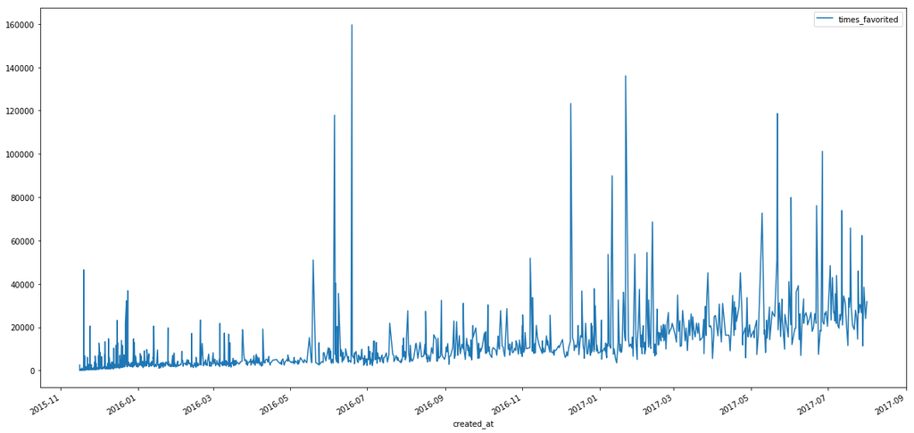

```python
#Let's see if there's a correlation between posting date and number of favorites
full_dog_final.plot.line(x='created_at', y='times_favorited', figsize=(20,10))
```

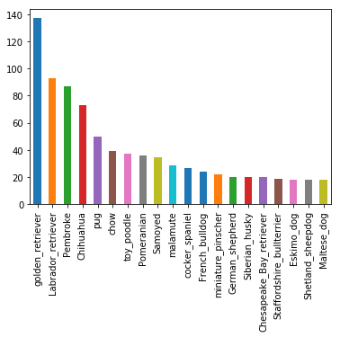

```python
full_dog_final_2['guess_1'].value_counts().head(20).plot.bar(x='guess_1')
```

```python
top_20_df = full_dog_final[['true_rating_perc','guess_1']].sort_values(by=['true_rating_perc'], ascending=False).head(20).reset_index()
```

```python
top_20_df.drop(columns='index',inplace=True)
```

```python
top_20_df
```

|  | true_rating_perc | guess_1 |
| --- | --- | --- |
| 0 | 750.000000 | Pomeranian |
| 1 | 342.857143 | golden_retriever |
| 2 | 270.000000 | clumber |
| 3 | 260.000000 | kuvasz |
| 4 | 140.000000 | Old_English_sheepdog |
| 5 | 140.000000 | Gordon_setter |
| 6 | 140.000000 | Irish_setter |
| 7 | 140.000000 | Pembroke |
| 8 | 140.000000 | French_bulldog |
| 9 | 140.000000 | bloodhound |
| 10 | 140.000000 | Pembroke |
| 11 | 140.000000 | Pembroke |
| 12 | 140.000000 | French_bulldog |
| 13 | 140.000000 | Bedlington_terrier |
| 14 | 140.000000 | standard_poodle |
| 15 | 140.000000 | Lakeland_terrier |
| 16 | 140.000000 | Eskimo_dog |
| 17 | 140.000000 | black-and-tan_coonhound |
| 18 | 140.000000 | golden_retriever |
| 19 | 140.000000 | Chihuahua |

```python
full_dog_final_2 = full_dog_final.drop(full_dog_final[full_dog_final.true_rating_perc > 140].index)
```

Second interesting insight. It seems that though the Pembroke ranks 3rd in most posted breed, it appears to have more higher rankings than any other breed. Landing 3 spots in the top 20, more than any other breed.

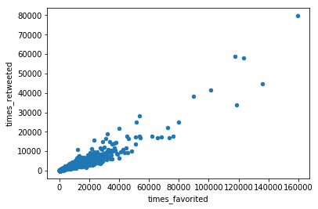

```python
full_dog_final_2.plot.scatter(x='times_favorited', y= 'times_retweeted')
```

There's a pretty unsurprisingly positive corellation between the times a post was retweeted and the times it was favorited.